# Analyses

Non preregistered analyses - alternative Bayesian metaanalytic models

Ian Hussey

25 January 2021

The original preregistration for the studies contained both hypotheses and the specific analytic strategies that would be used to test them. However, these preregistrations did not include a meta-analytic strategy. Separately, a number of research questions/hypotheses were generated from exploration of the data from Experiments 1-6 that were not contained in the original preregistration, or where the specific analytic strategy to test them was not precisely specified or difficult to interpret. Separately, some methodological improvements were thought of after Experiments 1-6 was run (e.g., improved exclusion criteria to ensure participants stayed on the page where they watched/listened to the intervention in its entirety). We therefore elected to use the data from Experiments 1-6 to create this (non-preregistered) alternative analytic strategy that formalized our core research questions, hypotheses, analytic models, inference rules, and other researcher degrees of freedom. This analytic strategy (and code to implement it) will be preregistered for Experiment 7 which will provide strong confirmatory tests of these hypotheses.

# Dependencies & functions

```r
# dependencies
library(tidyverse)
library(knitr)
library(kableExtra)
library(brms)
library(parallel)
library(tidybayes)
library(bayestestR)
library(sjPlot)
library(psych)
library(rsample)
library(broom)
library(purrr)
library(IATscores)
library(lavaan)
library(semTools)
library(modelr)
library(furrr)
library(caret)
library(e1071)

# set up parallel processing
#future::plan(multiprocess)

# knitr options
options(knitr.kable.NA = "/")

# set seed for bootstrapping reproducibility
set.seed(42)

# create necessary folder
dir.create("models")
```

# Exclusions & standaridization

All dependent variables (self-reported ratings, IAT D2 scores, behavioral intentions) were standardized (by 1 SD) after exclusions and prior to analysis condition (see Lorah, 2018: https://doi.org/10.1186/s40536-018-0061-2). This was done within each level of both IV (i.e., by Source Valence condition [positive vs. negative], and by Video Content [Genuine vs. Deepfaked]). As such, the beta estimates obtained from the Bayesian models (see research questions and data analysis plans below) therefore represent standardized beta values ($\beta$ rather than $B$). More importantly, the nature of this standardization makes these estimates somewhat comparable to the frequentist standardized effect size metric Cohen’s $d$, as both are a differences in (estimated) means as a proportion of SD although they should not be treated as equivalent. Effect size magnitude here can therefore be thought of along comparable scales as Cohen’s $d$. As such, to aid interpretability, the point estimates of effect size will be reported as $\delta$ (delta).

```r
# full data
data_processed <- read.csv("../data/processed/4_data_participant_level_with_hand_scoring.csv") %>%
  # include only experiments 1-6
  filter(experiment %in% c(1, 2, 3, 4, 5, 6)) %>%
  # set factor levels for t test comparisons
  mutate(source_valence = fct_relevel(source_valence,
                                      "negative",
                                      "positive"),
         experiment_condition = fct_relevel(experiment_condition,
                                            "genuine",
                                            "deepfaked"),
         experiment = as.factor(experiment))

# apply exclusions
data_after_exclusions <- data_processed %>%
  filter(exclude_subject == FALSE &
           exclude_implausible_intervention_linger == FALSE) %>%
  # standardize DVs by 1SD within each experiment and their conditions
  group_by(experiment, experiment_condition, source_valence) %>%
  mutate(mean_self_reported_evaluation = mean_self_reported_evaluation/sd(mean_self_reported_evaluation),
         IAT_D2 = IAT_D2/sd(IAT_D2),
         mean_intentions = mean_intentions/sd(mean_intentions)) %>%
  ungroup()

# item level for iat
data_iat_item_level_after_exclusions <- read_csv("../data/processed/2.4_data_iat_item_level.csv") %>%
  # exclude the same participants as above
  semi_join(rename(data_after_exclusions, subject_original = subject), by = "subject_original")
```

# Distributions

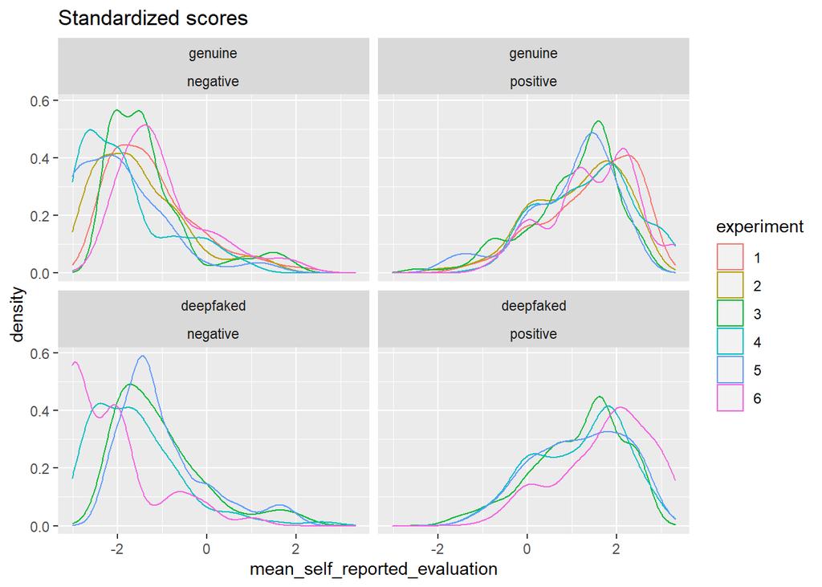

```r
ggplot(data_after_exclusions, aes(mean_self_reported_evaluation, color = experiment)) +
  geom_density() +
  facet_wrap( ~ experiment_condition + source_valence) +
  ggtitle("Standardized scores")
```

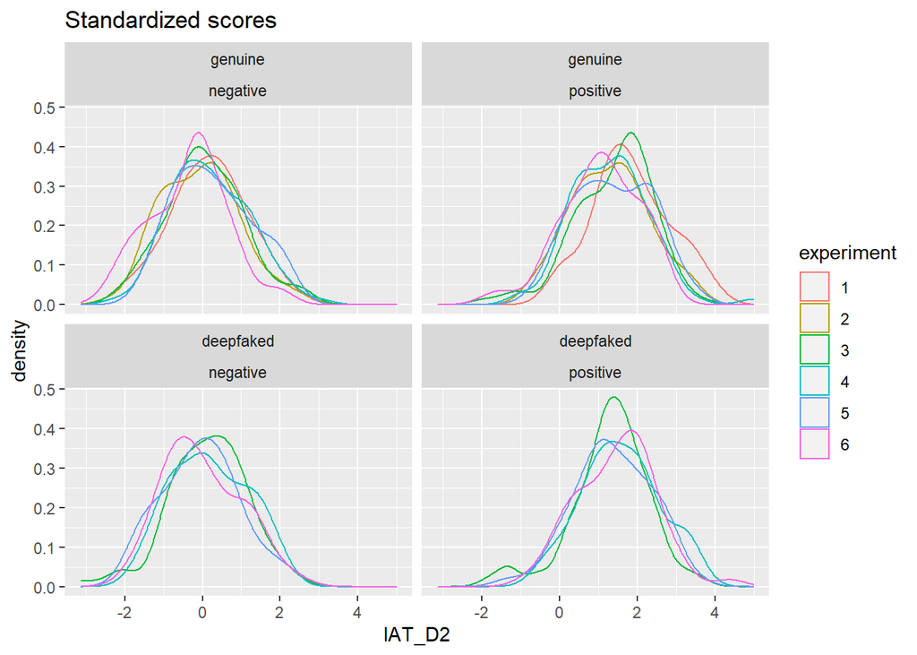

```r
ggplot(data_after_exclusions, aes(IAT_D2, color = experiment)) +
  geom_density() +
  facet_wrap( ~ experiment_condition + source_valence) +
  ggtitle("Standardized scores")
```

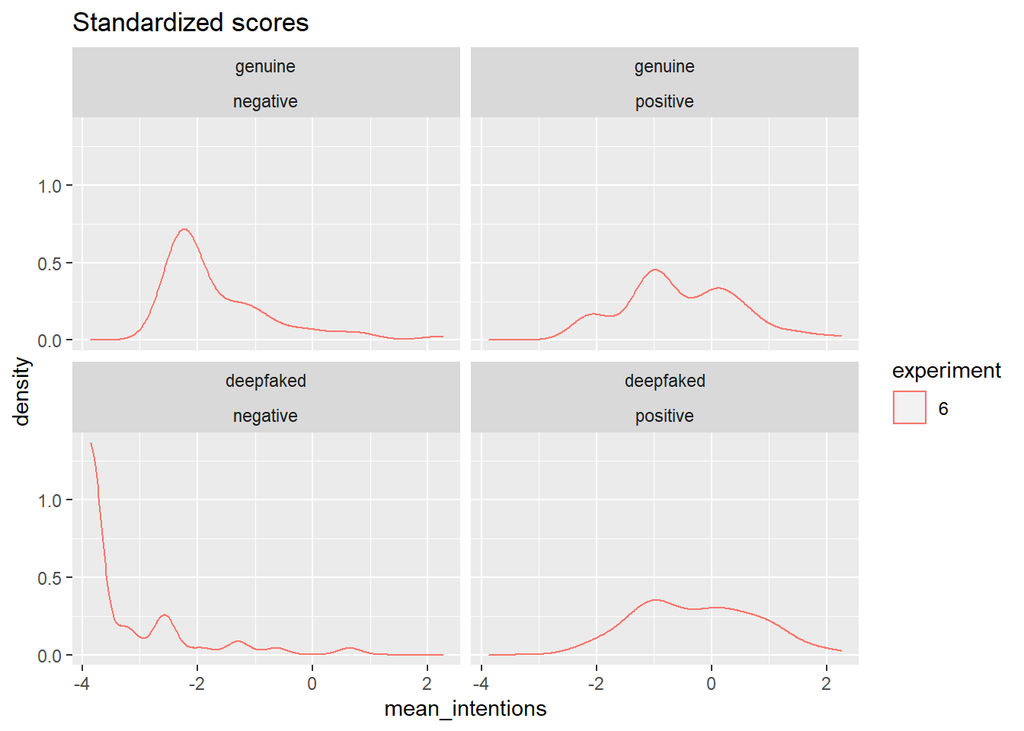

```r
ggplot(data_after_exclusions, aes(mean_intentions, color = experiment)) +
  geom_density() +
  facet_wrap( ~ experiment_condition + source_valence) +
  ggtitle("Standardized scores")
```

# Demographics

## Pre exclussion

```r
data_processed %>%
  group_by(experiment) %>%
  summarise(n = n(),
            excluded_n = sum(exclude_subject > 0 | exclude_implausible_intervention_linger > 0),
            excluded_percent = (excluded_n / n) *100) %>%
  mutate_if(is.numeric, round, digits = 1) %>%
  kable(align = "c") %>%
  kable_styling(bootstrap_options = c("striped", "hover", "condensed"),
                full_width = FALSE)
```

| experiment | n | excluded_n | excluded_percent |
| --- | --- | --- | --- |
| 1 | 165 | 24 | 14.5 |
| 2 | 167 | 36 | 21.6 |
| 3 | 428 | 91 | 21.3 |
| 4 | 429 | 106 | 24.7 |
| 5 | 276 | 66 | 23.9 |
| 6 | 265 | 61 | 23.0 |

## Post exclusions

```r
data_after_exclusions %>%
  group_by(experiment) %>%
  summarise(n = n(),
            age_mean = mean(age, na.rm = TRUE),
            age_sd = sd(age, na.rm = TRUE)) %>%
  mutate_if(is.numeric, round, digits = 1) %>%
  kable(align = "c") %>%
  kable_styling(bootstrap_options = c("striped", "hover", "condensed"),
                full_width = FALSE)
```

| experiment | n | age_mean | age_sd |
| --- | --- | --- | --- |
| 1 | 141 | 29.7 | 7.6 |
| 2 | 131 | 31.1 | 7.3 |
| 3 | 337 | 29.8 | 8.7 |
| 4 | 323 | 30.1 | 9.0 |
| 5 | 210 | 31.2 | 11.5 |
| 6 | 204 | 33.3 | 12.5 |

```r
data_after_exclusions %>%
  count(experiment, gender) %>%
  spread(gender, n) %>%
  kable(knitr.kable.NA = "/", align = "c") %>%
  kable_styling(bootstrap_options = c("striped", "hover", "condensed"),
                full_width = FALSE)
```

| experiment | female | male | Non-binary | other | Prefer not to disclose |
| --- | --- | --- | --- | --- | --- |
| 1 | 67 | 73 | / | 1 | / |
| 2 | 76 | 55 | / | / | / |
| 3 | 184 | 149 | / | 4 | / |
| 4 | 189 | 132 | / | 2 | / |
| 5 | 119 | 88 | 2 | / | 1 |
| 6 | 120 | 82 | 2 | / | / |

# Internal consistency

## Self-reported evaluations

```r
model_sr <- "scale =~ ratings_bad_good + ratings_dislike_like + ratings_negative_positive"

fit_cfa_sr <- data_after_exclusions %>%
  cfa(model = model_sr, data = .)

results_reliability_sr <- fit_cfa_sr %>%
  reliability() %>%
  as.data.frame() %>%
  rownames_to_column(var = "metric") %>%
  select(metric, estimate = scale) %>%
  filter(metric %in% c("alpha",
                       "omega2")) %>%
  mutate(metric = recode(metric,
                         "alpha" = "alpha",
                         "omega2" = "omega_t"),
         estimate = round(estimate, 3))

results_reliability_sr %>%
  kable(knitr.kable.NA = "/", align = "c") %>%
  kable_styling(bootstrap_options = c("striped", "hover", "condensed"),
                full_width = FALSE)
```

| metric | estimate |
| --- | --- |
| alpha | 0.987 |
| omega_t | 0.987 |

## IAT

split half

```r
results_iat_split_half_reliability <- data_iat_item_level_after_exclusions %>%
  SplitHalf.D2(IATdata = .) %>%
  mutate(algorithm = ifelse(algorithm == "p2112", "D2", algorithm),
         splithalf = round(splithalf, 3))
```

[output not shown]

```r
results_iat_split_half_reliability %>%
  kable(knitr.kable.NA = "/", align = "c") %>%
  kable_styling(bootstrap_options = c("striped", "hover", "condensed"),
                full_width = FALSE)
```

| algorithm | splithalf |
| --- | --- |
| D2 | 0.839 |

## Behavioral intentions

```r
model_bi <- "scale =~ behavioral_intentions_share + behavioral_intentions_subscribe + behavioral_intentions_recommend"

fit_cfa_bi <- data_after_exclusions %>%
  cfa(model = model_bi, data = .)

results_reliability_bi <- fit_cfa_bi %>%
  reliability() %>%
  as.data.frame() %>%
  rownames_to_column(var = "metric") %>%
  select(metric, estimate = scale) %>%
  filter(metric %in% c("alpha",
                       "omega2")) %>%
  mutate(metric = recode(metric,
                         "alpha" = "alpha",
                         "omega2" = "omega_t"),
         estimate = round(estimate, 3))

results_reliability_bi %>%
  kable(knitr.kable.NA = "/", align = "c") %>%
  kable_styling(bootstrap_options = c("striped", "hover", "condensed"),
                full_width = FALSE)
```

| metric | estimate |
| --- | --- |
| alpha | 0.941 |
| omega_t | 0.941 |

# RQ1 & RQ2: Can online content establish first impressions towards a novel individual?; Are Deepfakes just as good as genuine online content at establishing first impressions?

- Analyses employ Bayesian multilevel models with experiment employed as a random (Group level) intercept, and source_valence, experiment_condition and their interaction as IVs. This could therefore be described as akin to a Bayesian multilevel ANOVA.
- DVs were standardize as noted above, and as such fitted model estimates represent standardized beta values (which due to the specifics of the standardization have comparable [but not exact] interpretation as Cohen’s d values).
- Bayesian p values are also reported: these are on a similar scale to frequentist p values, but technically are 1 minus the posterior probability that the effect is greater than 0, i.e., $1 - P(\beta>0)$.
- Inspection of the posterior distributions allow us to infer that we employed weak priors placed on all parameters (normal distribution with M = 0 and SD = 10). Inspection of the chains indicated good convergence in all cases.

H1 hypotheses were tested using a Bayesian linear model to estimate a 95% Credible Interval on standardized effect size change in evaluations between Source Valence conditions. Credible Intervals whose lower bounds were > 0 were considered evidence in support of a given hypothesis.

For H2, if the lower bound of the 95% CI of the genuine condition is < the lower bound of the 90% CI of the Deepfaked condition (i.e., the difference between Source Valence conditions in each subgroups), this as considered evidence in support of the alternative hypothesis (i.e., evidence of non-inferiority in estimated means; that Deepfakes are as good as genuine content).

## Sample sizes

```r
data_after_exclusions %>%
  select(source_valence,
         experiment_condition) %>%
  drop_na() %>%
  count(experiment_condition,
        source_valence) %>%
  kable() %>%
  kable_styling(bootstrap_options = c("striped", "hover", "condensed"),
                full_width = FALSE)
```

| experiment_condition | source_valence | n |
| --- | --- | --- |
| genuine | negative | 382 |
| genuine | positive | 425 |
| deepfaked | negative | 257 |
| deepfaked | positive | 282 |

## Self-reported evaluations

### Fit model

```r
fit_exploratory_selfreport <-
  brm(formula = mean_self_reported_evaluation ~ source_valence * experiment_condition + (1 | experiment),
      family  = gaussian(),
      data    = data_after_exclusions,
      file    = "models/fit_exploratory_selfreport",
      prior   = prior(normal(0, 10)),
      iter    = 10000,
      warmup  = 3000,
      control = list(adapt_delta = 0.99),  # to avoid divergent transitions
      chains  = 4,
      cores   = parallel::detectCores())
```

### Inspect convergence

```r
summary(fit_exploratory_selfreport)
```

```
##  Family: gaussian
##   Links: mu = identity; sigma = identity
## Formula: mean_self_reported_evaluation ~ source_valence * experiment_condition + (1 | experiment)
##    Data: data_after_exclusions (Number of observations: 1346)
## Samples: 4 chains, each with iter = 10000; warmup = 3000; thin = 1;
##          total post-warmup samples = 28000
##
## Group-Level Effects:
## ~experiment (Number of levels: 6)
##               Estimate Est.Error l-95% CI u-95% CI Rhat Bulk_ESS Tail_ESS
## sd(Intercept)     0.18      0.11     0.06     0.45 1.00     6062    10346
##
## Population-Level Effects:
##                                                      Estimate Est.Error
## Intercept                                               -1.48      0.10
## source_valencepositive                                   2.71      0.07
## experiment_conditiondeepfaked                            0.08      0.09
## source_valencepositive:experiment_conditiondeepfaked     0.01      0.12
##                                                      l-95% CI u-95% CI Rhat
## Intercept                                               -1.67    -1.28 1.00
## source_valencepositive                                   2.56     2.85 1.00
## experiment_conditiondeepfaked                           -0.09     0.25 1.00
## source_valencepositive:experiment_conditiondeepfaked    -0.22     0.23 1.00
##                                                      Bulk_ESS Tail_ESS
## Intercept                                                9436    10696
## source_valencepositive                                  16185    19241
## experiment_conditiondeepfaked                           15506    17346
## source_valencepositive:experiment_conditiondeepfaked    14095    17133
##
## Family Specific Parameters:
##       Estimate Est.Error l-95% CI u-95% CI Rhat Bulk_ESS Tail_ESS
## sigma     1.03      0.02     1.00     1.07 1.00    22984    19026
##
## Samples were drawn using sampling(NUTS). For each parameter, Bulk_ESS
## and Tail_ESS are effective sample size measures, and Rhat is the potential
## scale reduction factor on split chains (at convergence, Rhat = 1).
```

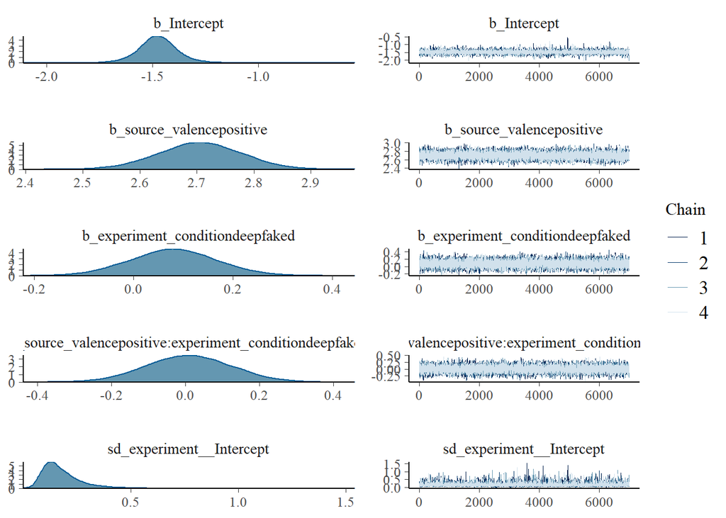

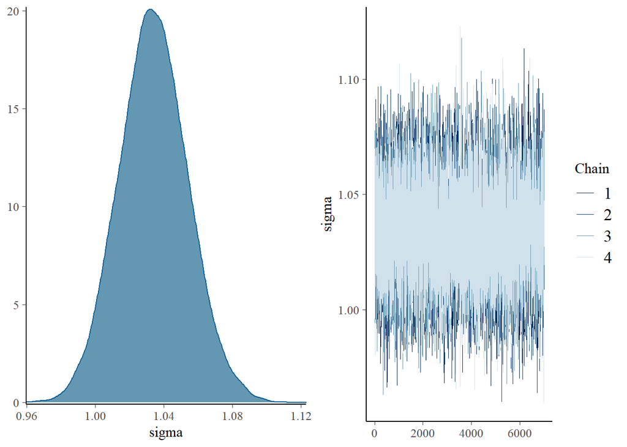

```r
plot(fit_exploratory_selfreport, ask = FALSE)
```

### Check informativeness of prior

Using Gelman’s (2019) simple heuristic: For each parameter, compare the posterior sd to the prior sd. If the posterior sd for any parameter is more than 0.1 times the prior sd, then note that the prior was informative.

```r
check_prior(fit_exploratory_selfreport) %>%
  kable() %>%
  kable_styling(bootstrap_options = c("striped", "hover", "condensed"),
                full_width = FALSE)
```

| Parameter | Prior_Quality |
| --- | --- |
| b_Intercept | uninformative |
| b_source_valencepositive | uninformative |
| b_experiment_conditiondeepfaked | uninformative |
| b_source_valencepositive.experiment_conditiondeepfaked | uninformative |

### Interpret posteriors

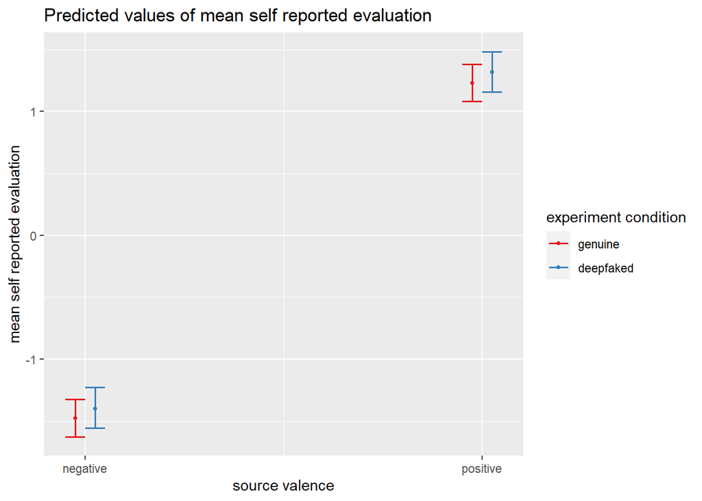

```r
# plot_model(fit_exploratory_selfreport)
plot_model(fit_exploratory_selfreport, type = "pred", terms = c("source_valence", "experiment_condition"))
```

```r
# percent moderation
draws_sr <-
  bind_cols(
    select(spread_draws(fit_exploratory_selfreport, b_source_valencepositive), b_source_valencepositive),
    select(spread_draws(fit_exploratory_selfreport, b_experiment_conditiondeepfaked), b_experiment_conditiondeepfaked),
    select(spread_draws(fit_exploratory_selfreport, `b_source_valencepositive:experiment_conditiondeepfaked`), `b_source_valencepositive:experiment_conditiondeepfaked`)
  ) %>%
  rename(main_valence = b_source_valencepositive,
         main_experiment_condition = b_experiment_conditiondeepfaked,
         interaction = `b_source_valencepositive:experiment_conditiondeepfaked`) %>%
  mutate(effect_genuine = main_valence,
         effect_deepfaked = main_valence + interaction,
         #percent_moderation = (main_experiment_condition + interaction)/main_valence *100,  # alt method, same result
         percent_comparison = (effect_deepfaked/effect_genuine)*100)

# results
estimates_sr <-
  map_estimate(draws_sr) %>%
  full_join(bayestestR::hdi(draws_sr, ci = .95) %>%
              rename(CI_95_lower = CI_low,
                     CI_95_upper = CI_high) %>%
              as_tibble(),
            by = "Parameter") %>%
  full_join(bayestestR::hdi(draws_sr, ci = .90) %>%
              as_tibble() %>%
              rename(CI_90_lower = CI_low,
                     CI_90_upper = CI_high),
            by = "Parameter") %>%
  full_join(draws_sr %>%
              select(-percent_comparison) %>%
              gather(Parameter, value) %>%
              group_by(Parameter) %>%
              summarize(pd = mean(value > 0)) %>%
              mutate(p = pd_to_p(pd, direction = "one-sided")) %>%
              ungroup() %>%
              select(Parameter, p),
            by = "Parameter") %>%
  select(Parameter, MAP_Estimate, CI_95_lower, CI_95_upper,
         CI_90_lower, CI_90_upper, p)

# results table
estimates_sr %>%
  mutate_at(.vars = c("MAP_Estimate", "CI_95_lower", "CI_95_upper", "CI_90_lower", "CI_90_upper"), round, digits = 2) %>%
  kable() %>%
  kable_styling(bootstrap_options = c("striped", "hover", "condensed"),
                full_width = FALSE)
```

| Parameter | MAP_Estimate | CI_95_lower | CI_95_upper | CI_90_lower | CI_90_upper | p |
| --- | --- | --- | --- | --- | --- | --- |
| main_valence | 2.71 | 2.57 | 2.85 | 2.58 | 2.82 | 0.0000000 |
| main_experiment_condition | 0.08 | -0.09 | 0.25 | -0.06 | 0.22 | 0.1792857 |
| interaction | 0.02 | -0.21 | 0.24 | -0.19 | 0.19 | 0.4719286 |
| effect_genuine | 2.71 | 2.57 | 2.85 | 2.58 | 2.82 | 0.0000000 |
| effect_deepfaked | 2.71 | 2.53 | 2.88 | 2.57 | 2.86 | 0.0000000 |
| percent_comparison | 100.45 | 92.14 | 108.84 | 93.42 | 107.40 | / |

```r
# hypothesis testing
H1a <- ifelse((estimates_sr %>% filter(Parameter == "effect_genuine") %>% pull(CI_95_lower)) > 0,
              "Accepted", "Rejected")

H1b <- ifelse((estimates_sr %>% filter(Parameter == "effect_deepfaked") %>% pull(CI_95_lower)) > 0,
              "Accepted", "Rejected")

H2a <- ifelse((estimates_sr %>% filter(Parameter == "effect_deepfaked") %>% pull(CI_90_lower)) >
                (estimates_sr %>% filter(Parameter == "effect_genuine") %>% pull(CI_95_lower)),
              "Accepted", "Rejected")

comparison_string_sr <-
  paste0("Deepfakes are ",
         estimates_sr %>% filter(Parameter == "percent_comparison") %>% pull(MAP_Estimate) %>% round(1),
         "% (95% CI [",
         estimates_sr %>% filter(Parameter == "percent_comparison") %>% pull(CI_95_lower) %>% round(1),
         ", ",
         estimates_sr %>% filter(Parameter == "percent_comparison") %>% pull(CI_95_upper) %>% round(1),
         "]) as effective as genuine content in establishing self-reported evaluations")
```

*H1a*

The content of the genuine videos (i.e., Source Valence) will influence participants’ self-reported evaluations.

- Result: Accepted

*H1b*

The content of the Deepfaked videos (i.e., Source Valence) will influence participants’ self-reported evaluations.

- Result: Accepted

*H2a*

Change in self-reported evaluations (i.e., between Source Valence conditions) induced by Deepfaked video content will be non-inferior to genuine content.

- Result: Accepted. Deepfakes are 100.4% (95% CI [92.1, 108.8]) as effective as genuine content in establishing self-reported evaluations.

## Implicit

### Fit model

```r
fit_exploratory_implicit <-
  brm(formula = IAT_D2 ~ source_valence * experiment_condition + (1 | experiment),
      family  = gaussian(),
      data    = data_after_exclusions,
      file    = "models/fit_exploratory_implicit",
      prior   = prior(normal(0, 10)),
      iter    = 10000,
      warmup  = 3000,
      control = list(adapt_delta = 0.99),  # to avoid divergent transitions
      chains  = 4,
      cores   = parallel::detectCores())
```

### Inspect convergence

```r
summary(fit_exploratory_implicit)
```

```
##  Family: gaussian
##   Links: mu = identity; sigma = identity
## Formula: IAT_D2 ~ source_valence * experiment_condition + (1 | experiment)
##    Data: data_after_exclusions (Number of observations: 1346)
## Samples: 4 chains, each with iter = 10000; warmup = 3000; thin = 1;
##          total post-warmup samples = 28000
##
## Group-Level Effects:
## ~experiment (Number of levels: 6)
##               Estimate Est.Error l-95% CI u-95% CI Rhat Bulk_ESS Tail_ESS
## sd(Intercept)     0.20      0.11     0.07     0.49 1.00     6353    10078
##
## Population-Level Effects:
##                                                      Estimate Est.Error
## Intercept                                                0.05      0.11
## source_valencepositive                                   1.32      0.07
## experiment_conditiondeepfaked                            0.07      0.08
## source_valencepositive:experiment_conditiondeepfaked     0.00      0.11
##                                                      l-95% CI u-95% CI Rhat
## Intercept                                               -0.16     0.26 1.00
## source_valencepositive                                   1.19     1.46 1.00
## experiment_conditiondeepfaked                           -0.10     0.24 1.00
## source_valencepositive:experiment_conditiondeepfaked    -0.22     0.22 1.00
##                                                      Bulk_ESS Tail_ESS
## Intercept                                                8577    10726
## source_valencepositive                                  16062    17724
## experiment_conditiondeepfaked                           14240    17618
## source_valencepositive:experiment_conditiondeepfaked    13767    17652
##
## Family Specific Parameters:
##       Estimate Est.Error l-95% CI u-95% CI Rhat Bulk_ESS Tail_ESS
## sigma     1.00      0.02     0.97     1.04 1.00    21681    19247
##
## Samples were drawn using sampling(NUTS). For each parameter, Bulk_ESS
## and Tail_ESS are effective sample size measures, and Rhat is the potential
## scale reduction factor on split chains (at convergence, Rhat = 1).
```

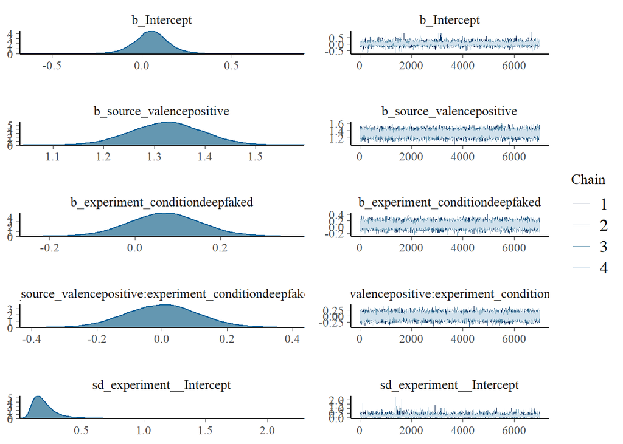

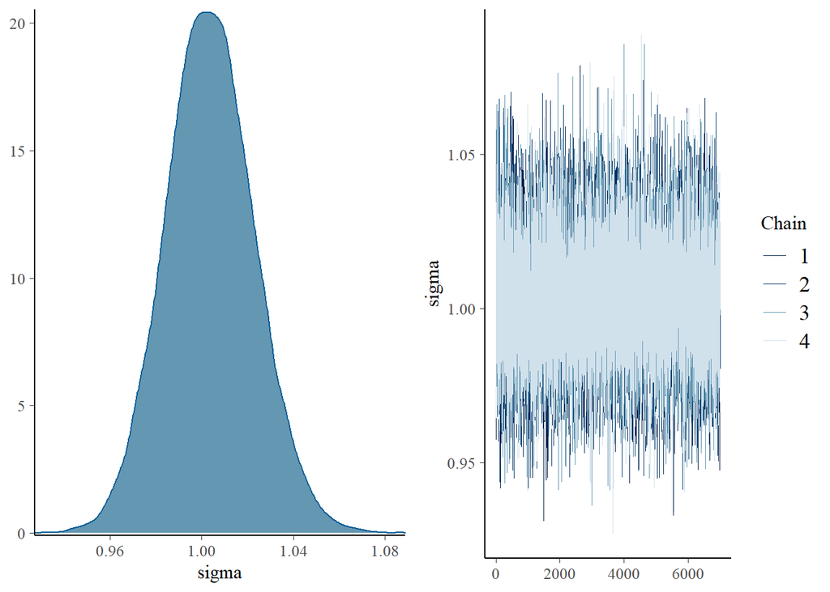

```r
plot(fit_exploratory_implicit, ask = FALSE)
```

### Check informativeness of prior

Using Gelman’s (2019) simple heuristic: For each parameter, compare the posterior sd to the prior sd. If the posterior sd for any parameter is more than 0.1 times the prior sd, then note that the prior was informative.

```r
check_prior(fit_exploratory_implicit) %>%
  kable() %>%
  kable_styling(bootstrap_options = c("striped", "hover", "condensed"),
                full_width = FALSE)
```

| Parameter | Prior_Quality |
| --- | --- |
| b_Intercept | uninformative |
| b_source_valencepositive | uninformative |
| b_experiment_conditiondeepfaked | uninformative |
| b_source_valencepositive.experiment_conditiondeepfaked | uninformative |

### Interpret posteriors

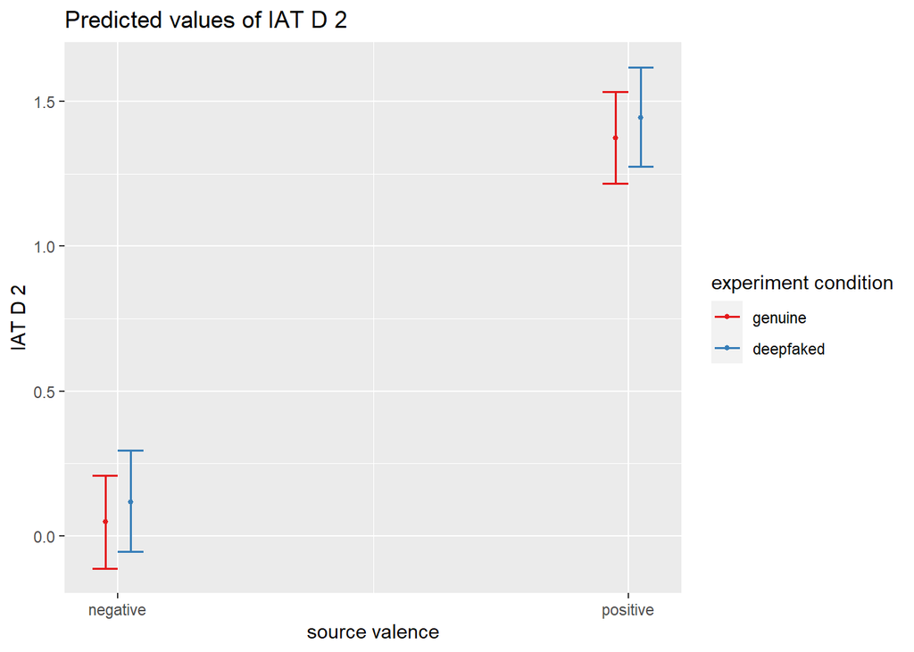

```r
#plot_model(fit_exploratory_implicit)
plot_model(fit_exploratory_implicit, type = "pred", terms = c("source_valence", "experiment_condition"))
```

```r
# percent moderation
draws_imp <-
  bind_cols(
    select(spread_draws(fit_exploratory_implicit, b_source_valencepositive), b_source_valencepositive),
    select(spread_draws(fit_exploratory_implicit, b_experiment_conditiondeepfaked), b_experiment_conditiondeepfaked),
    select(spread_draws(fit_exploratory_implicit, `b_source_valencepositive:experiment_conditiondeepfaked`), `b_source_valencepositive:experiment_conditiondeepfaked`)
  ) %>%
  rename(main_valence = b_source_valencepositive,
         main_experiment_condition = b_experiment_conditiondeepfaked,
         interaction = `b_source_valencepositive:experiment_conditiondeepfaked`) %>%
  mutate(effect_genuine = main_valence,
         effect_deepfaked = main_valence + interaction,
         #percent_moderation = (main_experiment_condition + interaction)/main_valence *100,  # alt method, same result
         percent_comparison = (effect_deepfaked/effect_genuine)*100)

# results table
estimates_imp <-
  map_estimate(draws_imp) %>%
  full_join(bayestestR::hdi(draws_imp, ci = .95) %>%
              rename(CI_95_lower = CI_low,
                     CI_95_upper = CI_high) %>%
              as_tibble(),
            by = "Parameter") %>%
  full_join(bayestestR::hdi(draws_imp, ci = .90) %>%
              as_tibble() %>%
              rename(CI_90_lower = CI_low,
                     CI_90_upper = CI_high),
            by = "Parameter") %>%
  full_join(draws_imp %>%
              select(-percent_comparison) %>%
              gather(Parameter, value) %>%
              group_by(Parameter) %>%
              summarize(pd = mean(value > 0)) %>%
              mutate(p = pd_to_p(pd, direction = "one-sided")) %>%
              ungroup() %>%
              select(Parameter, p),
            by = "Parameter") %>%
  select(Parameter, MAP_Estimate, CI_95_lower, CI_95_upper,
         CI_90_lower, CI_90_upper, p)

estimates_imp %>%
  mutate_at(.vars = c("MAP_Estimate", "CI_95_lower", "CI_95_upper", "CI_90_lower", "CI_90_upper"), round, digits = 2) %>%
  kable() %>%
  kable_styling(bootstrap_options = c("striped", "hover", "condensed"),
                full_width = FALSE)
```

| Parameter | MAP_Estimate | CI_95_lower | CI_95_upper | CI_90_lower | CI_90_upper | p |
| --- | --- | --- | --- | --- | --- | --- |
| main_valence | 1.33 | 1.19 | 1.46 | 1.21 | 1.44 | 0.0000000 |
| main_experiment_condition | 0.07 | -0.10 | 0.23 | -0.07 | 0.21 | 0.2023571 |
| interaction | 0.01 | -0.22 | 0.22 | -0.18 | 0.18 | 0.4975000 |
| effect_genuine | 1.33 | 1.19 | 1.46 | 1.21 | 1.44 | 0.0000000 |
| effect_deepfaked | 1.32 | 1.16 | 1.49 | 1.18 | 1.47 | 0.0000000 |
| percent_comparison | 100.28 | 83.91 | 117.07 | 86.13 | 113.81 | / |

```r
# hypothesis testing
H1c <- ifelse((estimates_imp %>% filter(Parameter == "effect_genuine") %>% pull(CI_95_lower)) > 0,
              "Accepted", "Rejected")

H1d <- ifelse((estimates_imp %>% filter(Parameter == "effect_deepfaked") %>% pull(CI_95_lower)) > 0,
              "Accepted", "Rejected")

H2b <- ifelse((estimates_imp %>% filter(Parameter == "effect_deepfaked") %>% pull(CI_90_lower)) >
                (estimates_imp %>% filter(Parameter == "effect_genuine") %>% pull(CI_95_lower)),
              "Accepted", "Rejected")

comparison_string_imp <-
  paste0("Deepfakes are ",
         estimates_imp %>% filter(Parameter == "percent_comparison") %>% pull(MAP_Estimate) %>% round(1),
         "% (95% CI [",
         estimates_imp %>% filter(Parameter == "percent_comparison") %>% pull(CI_95_lower) %>% round(1),
         ", ",
         estimates_imp %>% filter(Parameter == "percent_comparison") %>% pull(CI_95_upper) %>% round(1),
         "]) as effective as genuine content in establishing self-reported evaluations")
```

*H1c*

The content of the genuine videos (i.e., Source Valence) will influence participants’ IAT D2 scores.

- Result: Accepted

*H1d*

The content of the Deepfaked videos (i.e., Source Valence) will influence participants’ IAT D2 scores.

- Result: Accepted

*H2b*

Change in IAT D2 scores (i.e., between Source Valence conditions) induced by Deepfaked video content will be non-inferior to genuine content.

- Result: Rejected. Deepfakes are 100.3% (95% CI [83.9, 117.1]) as effective as genuine content in establishing self-reported evaluations.

## Behavioural intentions

### Fit model

```r
fit_exploratory_intentions <-
  brm(formula = mean_intentions ~ source_valence * experiment_condition, # no random effect for experiment as only exp 6 assessed intentions
      family  = gaussian(),
      data    = data_after_exclusions,
      file    = "models/fit_exploratory_intentions",
      prior   = prior(normal(0, 10)),
      iter    = 10000,
      warmup  = 3000,
      control = list(adapt_delta = 0.99),  # to avoid divergent transitions
      chains  = 4,
      cores   = parallel::detectCores())
```

### Inspect convergence

```r
summary(fit_exploratory_intentions)
```

```
##  Family: gaussian
##   Links: mu = identity; sigma = identity
## Formula: mean_intentions ~ source_valence * experiment_condition
##    Data: data_after_exclusions (Number of observations: 204)
## Samples: 4 chains, each with iter = 10000; warmup = 3000; thin = 1;
##          total post-warmup samples = 28000
##
## Population-Level Effects:
##                                                      Estimate Est.Error
## Intercept                                               -1.63      0.14
## source_valencepositive                                   1.12      0.20
## experiment_conditiondeepfaked                           -1.70      0.20
## source_valencepositive:experiment_conditiondeepfaked     1.95      0.28
##                                                      l-95% CI u-95% CI Rhat
## Intercept                                               -1.91    -1.36 1.00
## source_valencepositive                                   0.72     1.51 1.00
## experiment_conditiondeepfaked                           -2.10    -1.30 1.00
## source_valencepositive:experiment_conditiondeepfaked     1.41     2.50 1.00
##                                                      Bulk_ESS Tail_ESS
## Intercept                                               14175    18291
## source_valencepositive                                  12578    16041
## experiment_conditiondeepfaked                           12236    14897
## source_valencepositive:experiment_conditiondeepfaked    10940    14705
##
## Family Specific Parameters:
##       Estimate Est.Error l-95% CI u-95% CI Rhat Bulk_ESS Tail_ESS
## sigma     1.01      0.05     0.91     1.11 1.00    20033    16506
##
## Samples were drawn using sampling(NUTS). For each parameter, Bulk_ESS
## and Tail_ESS are effective sample size measures, and Rhat is the potential
## scale reduction factor on split chains (at convergence, Rhat = 1).
```

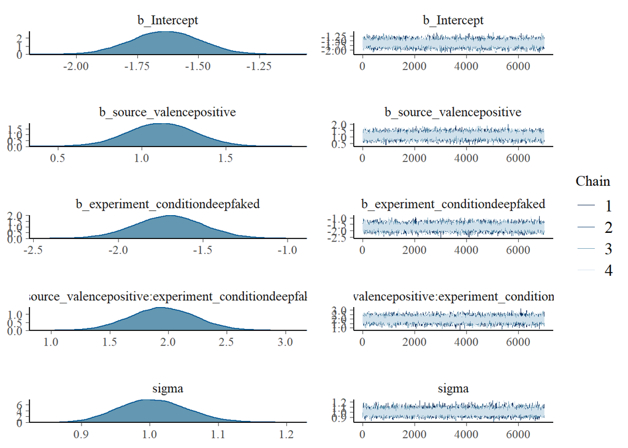

```r
plot(fit_exploratory_intentions, ask = FALSE)
```

### Check informativeness of prior

Using Gelman’s (2019) simple heuristic: For each parameter, compare the posterior sd to the prior sd. If the posterior sd for any parameter is more than 0.1 times the prior sd, then note that the prior was informative.

```r
check_prior(fit_exploratory_intentions) %>%
  kable() %>%
  kable_styling(bootstrap_options = c("striped", "hover", "condensed"),
                full_width = FALSE)
```

| Parameter | Prior_Quality |
| --- | --- |
| b_Intercept | uninformative |
| b_source_valencepositive | uninformative |
| b_experiment_conditiondeepfaked | uninformative |
| b_source_valencepositive.experiment_conditiondeepfaked | uninformative |

### Interpret posteriors

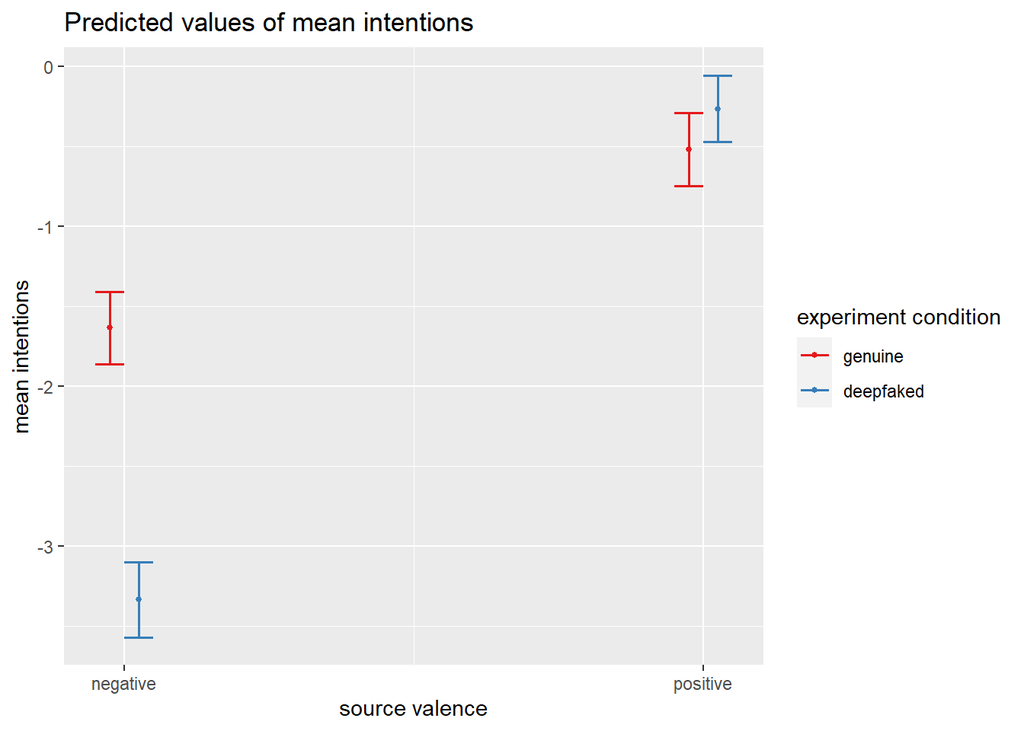

```r
#plot_model(fit_exploratory_intentions)
plot_model(fit_exploratory_intentions, type = "pred", terms = c("source_valence", "experiment_condition"))
```

```r
# percent moderation
draws_intentions <-
  bind_cols(
    select(spread_draws(fit_exploratory_intentions, b_source_valencepositive), b_source_valencepositive),
    select(spread_draws(fit_exploratory_intentions, b_experiment_conditiondeepfaked), b_experiment_conditiondeepfaked),
    select(spread_draws(fit_exploratory_intentions, `b_source_valencepositive:experiment_conditiondeepfaked`), `b_source_valencepositive:experiment_conditiondeepfaked`)
  ) %>%
  rename(main_valence = b_source_valencepositive,
         main_experiment_condition = b_experiment_conditiondeepfaked,
         interaction = `b_source_valencepositive:experiment_conditiondeepfaked`) %>%
  mutate(effect_genuine = main_valence,
         effect_deepfaked = main_valence + interaction,
         #percent_moderation = (main_experiment_condition + interaction)/main_valence *100,  # alt method, same result
         percent_comparison = (effect_deepfaked/effect_genuine)*100)

# results table
estimates_intentions <-
  map_estimate(draws_intentions) %>%
  full_join(bayestestR::hdi(draws_intentions, ci = .95) %>%
              rename(CI_95_lower = CI_low,
                     CI_95_upper = CI_high) %>%
              as_tibble(),
            by = "Parameter") %>%
  full_join(bayestestR::hdi(draws_intentions, ci = .90) %>%
              as_tibble() %>%
              rename(CI_90_lower = CI_low,
                     CI_90_upper = CI_high),
            by = "Parameter") %>%
  full_join(draws_intentions %>%
              select(-percent_comparison) %>%
              gather(Parameter, value) %>%
              group_by(Parameter) %>%
              summarize(pd = mean(value > 0)) %>%
              mutate(p = pd_to_p(pd, direction = "one-sided")) %>%
              ungroup() %>%
              select(Parameter, p),
            by = "Parameter") %>%
  select(Parameter, MAP_Estimate, CI_95_lower, CI_95_upper,
         CI_90_lower, CI_90_upper, p)

estimates_intentions %>%
  mutate_at(.vars = c("MAP_Estimate", "CI_95_lower", "CI_95_upper", "CI_90_lower", "CI_90_upper"), round, digits = 2) %>%
  kable() %>%
  kable_styling(bootstrap_options = c("striped", "hover", "condensed"),
                full_width = FALSE)
```

| Parameter | MAP_Estimate | CI_95_lower | CI_95_upper | CI_90_lower | CI_90_upper | p |
| --- | --- | --- | --- | --- | --- | --- |
| main_valence | 1.13 | 0.73 | 1.52 | 0.78 | 1.44 | 0 |
| main_experiment_condition | -1.69 | -2.10 | -1.30 | -2.03 | -1.36 | 0 |
| interaction | 1.93 | 1.41 | 2.50 | 1.49 | 2.41 | 0 |
| effect_genuine | 1.13 | 0.73 | 1.52 | 0.78 | 1.44 | 0 |
| effect_deepfaked | 3.06 | 2.67 | 3.45 | 2.75 | 3.41 | 0 |
| percent_comparison | 259.51 | 184.86 | 405.28 | 196.85 | 373.65 | / |

```r
# hypothesis testing
H1e <- ifelse((estimates_intentions %>% filter(Parameter == "effect_genuine") %>% pull(CI_95_lower)) > 0,
              "Accepted", "Rejected")

H1f <- ifelse((estimates_intentions %>% filter(Parameter == "effect_deepfaked") %>% pull(CI_95_lower)) > 0,
              "Accepted", "Rejected")

H2c <- ifelse((estimates_intentions %>% filter(Parameter == "effect_deepfaked") %>% pull(CI_90_lower)) >
                (estimates_intentions %>% filter(Parameter == "effect_genuine") %>% pull(CI_95_lower)),
              "Accepted", "Rejected")

comparison_string_intentions <-
  paste0("Deepfakes are ",
         estimates_intentions %>% filter(Parameter == "percent_comparison") %>% pull(MAP_Estimate) %>% round(1),
         "% (95% CI [",
         estimates_intentions %>% filter(Parameter == "percent_comparison") %>% pull(CI_95_lower) %>% round(1),
         ", ",
         estimates_intentions %>% filter(Parameter == "percent_comparison") %>% pull(CI_95_upper) %>% round(1),
         "]) as effective as genuine content in establishing self-reported evaluations")
```

*H1e*

The content of the genuine videos (i.e., Source Valence) will influence participants’ behavioral intention responses.

- Result: Accepted

*H1f*

The content of the Deepfaked videos (i.e., Source Valence) will influence participants’ behavioral intention responses.

- Result: Accepted

*H2c*

Change in behavioral intentions (i.e., between Source Valence conditions) induced by Deepfaked video content will be non-inferior to genuine content.

- Result: Accepted. Deepfakes are 259.5% (95% CI [184.9, 405.3]) as effective as genuine content in establishing self-reported evaluations.

# RQ3: How good are people at detecting Deepfakes?

## Inter-rater relibility

```r
data_after_exclusions %>%
  count(deepfake_detection_open_recoded,
        deepfake_detection_rater_1,
        deepfake_detection_rater_2) %>%
  kable() %>%
  kable_styling(bootstrap_options = c("striped", "hover", "condensed"),
                full_width = FALSE)
```

| deepfake_detection_open_recoded | deepfake_detection_rater_1 | deepfake_detection_rater_2 | n |
| --- | --- | --- | --- |
| FALSE | FALSE | FALSE | 414 |
| FALSE | FALSE | TRUE | 16 |
| FALSE | TRUE | FALSE | 31 |
| TRUE | TRUE | TRUE | 115 |
| / | / | / | 770 |

```r
data_after_exclusions %>%
  summarize(percent_agreement = round(mean(deepfake_detection_rater_1 == deepfake_detection_rater_2, na.rm = TRUE)*100, 1)) %>%
  kable() %>%
  kable_styling(bootstrap_options = c("striped", "hover", "condensed"),
                full_width = FALSE)
```

| percent_agreement |
| --- |
| 91.8 |

```r
data_after_exclusions %>%
  select(deepfake_detection_rater_1,
         deepfake_detection_rater_2) %>%
  as.data.frame() %>%  # kappa function won't take tibbles
  psych::cohen.kappa(.)
```

```
## Call: cohen.kappa1(x = x, w = w, n.obs = n.obs, alpha = alpha, levels = levels)
##
## Cohen Kappa and Weighted Kappa correlation coefficients and confidence boundaries
##                  lower estimate upper
## unweighted kappa  0.72     0.78  0.84
## weighted kappa    0.72     0.78  0.84
##
##  Number of subjects = 576
```

Interpretation of Kappa (Altman 1999, Landis JR, 1977):

- 0.61 - 0.80 Substantial
- 0.81 - 1.00 Almost perfect

## Can people accurately detect deepfakes?

### Sample size

```r
data_after_exclusions %>%
  count(experiment_condition,
        deepfake_detection_open_recoded) %>%
  drop_na() %>%
  mutate(deepfake_detection_open_recoded = case_when(deepfake_detection_open_recoded == "TRUE" ~ "deepfaked",
                                                     deepfake_detection_open_recoded == "FALSE" ~ "genuine")) %>%
  kable() %>%
  kable_styling(bootstrap_options = c("striped", "hover", "condensed"),
                full_width = FALSE)
```

| experiment_condition | deepfake_detection_open_recoded | n |
| --- | --- | --- |
| genuine | genuine | 188 |
| genuine | deepfaked | 16 |
| deepfaked | genuine | 273 |
| deepfaked | deepfaked | 99 |

### Classification stats

```r
data_classifications <- data_after_exclusions %>%
  select(experiment_condition, deepfake_detection_open_recoded) %>%
  drop_na() %>%
  mutate(deepfake_detection_open_recoded = case_when(deepfake_detection_open_recoded == "TRUE" ~ "deepfaked",
                                                     deepfake_detection_open_recoded == "FALSE" ~ "genuine"))

truth <- factor(data_classifications$experiment_condition,
                levels = rev(c("genuine", "deepfaked")))

pred <- factor(data_classifications$deepfake_detection_open_recoded,
               levels = rev(c("genuine", "deepfaked")))

cm <- confusionMatrix(table(pred, truth))

fit_confirmatory_classification <-
  as_tibble(cm$byClass, rownames = "parameter") %>%
  spread(parameter, value) %>%
  mutate(balanced_accuracy = `Balanced Accuracy`,
         false_negative_rate = 1 - Sensitivity,
         false_positive_rate = 1 - Specificity,
         informedness = Sensitivity + Specificity - 1) %>%
  select(balanced_accuracy,
         informedness,
         false_negative_rate,
         false_positive_rate) %>%
  gather(variable, observed, c(balanced_accuracy,
                               informedness,
                               false_negative_rate,
                               false_positive_rate))
```

### Bootstrapped classification stats

```r
# create bootstraps using out of bag method. makes a df with values that are collapsed dfs.
boots <- data_classifications %>%
  bootstraps(times = 2000)

# function to bootstrap classification stats and return a tibble
bootstrap_categorization_stats <- function(split) {

  truth <- factor(analysis(split)$experiment_condition,
                  levels = rev(c("genuine", "deepfaked")))

  pred <- factor(analysis(split)$deepfake_detection_open_recoded,
                 levels = rev(c("genuine", "deepfaked")))

  cm <- confusionMatrix(table(pred, truth))

  results <-
    as_tibble(cm$byClass, rownames = "parameter") %>%
    spread(parameter, value) %>%
    mutate(balanced_accuracy = `Balanced Accuracy`,
           false_negative_rate = 1 - Sensitivity,
           false_positive_rate = 1 - Specificity,
           informedness = Sensitivity + Specificity - 1) %>%
    select(balanced_accuracy,
           informedness,
           false_negative_rate,
           false_positive_rate)

  return(results)
}

# apply to each bootstrap
fit_confirmatory_classification_bootstraps <- boots %>%
  mutate(categorization_stats = future_map(splits, bootstrap_categorization_stats)) %>%
  select(-splits) %>%
  unnest(categorization_stats)
```

### Results

```r
classifications <- fit_confirmatory_classification_bootstraps %>%
  gather(variable, value, c(balanced_accuracy,
                            informedness,
                            false_negative_rate,
                            false_positive_rate)) %>%
  group_by(variable) %>%
  summarize(ci_lower = quantile(value, 0.025),
            ci_upper = quantile(value, 0.975),
            .groups  = "drop") %>%
  full_join(fit_confirmatory_classification, by = "variable") %>%
  mutate_if(is.numeric, round, digits = 2) %>%
  select(variable, observed, ci_lower, ci_upper)

classifications %>%
  kable() %>%
  kable_styling(bootstrap_options = c("striped", "hover", "condensed"),
                full_width = FALSE)
```

| variable | observed | ci_lower | ci_upper |
| --- | --- | --- | --- |
| balanced_accuracy | 0.59 | 0.56 | 0.62 |
| false_negative_rate | 0.73 | 0.69 | 0.78 |
| false_positive_rate | 0.08 | 0.04 | 0.12 |
| informedness | 0.19 | 0.13 | 0.25 |

H3: Participants are poor at making accurate and informed judgements about whether online video content is genuine or Deepfaked. Our predictions here are descriptive/continuous rather than involving cut-off based inference rules.

- H3a. We expect a substantial proportion of participants to be poor at correctly detecting Deepfakes. This will be examined using the false negative rate, although we do not have numerical predictions here.
- H3b. We expect a substantial proportion of participants to incorrectly detect Deepfakes even when the video content was real/.This will be examined using the false positive rate, although we do not have numerical predictions here.
- H3c. We expect participants to be poor at making accurate decisions about whether content is genuine or not (e.g., Balanced Accuracy not greatly above chance, circa .60), far less than what might be considered highly accurate decisions (e.g., BA of .80 or .90).
- H3d. We expect participants to make poorly informed decisions about whether content is genuine or not, (e.g., informedness/Youden’s J of circa .20), far less than what might be considered highly informed decisions (e.g., J of .80 or .90).

## Even the subset of participants who were aware of the concept of Deepfakes before the study?

Same descriptive predictions as above.

### Sample size

```r
data_after_exclusions %>%
  filter(deepfake_awareness_open_recoded == TRUE) %>%
  count(experiment_condition,
        deepfake_detection_open_recoded) %>%
  drop_na() %>%
  mutate(deepfake_detection_open_recoded = case_when(deepfake_detection_open_recoded == "TRUE" ~ "deepfaked",
                                                     deepfake_detection_open_recoded == "FALSE" ~ "genuine")) %>%
  kable() %>%
  kable_styling(bootstrap_options = c("striped", "hover", "condensed"),
                full_width = FALSE)
```

| experiment_condition | deepfake_detection_open_recoded | n |
| --- | --- | --- |
| genuine | genuine | 96 |
| genuine | deepfaked | 10 |
| deepfaked | genuine | 82 |
| deepfaked | deepfaked | 32 |

### Classification stats

```r
data_classifications_subset <- data_after_exclusions %>%
  filter(deepfake_awareness_open_recoded == TRUE) %>%
  select(experiment_condition, deepfake_detection_open_recoded) %>%
  drop_na() %>%
  mutate(deepfake_detection_open_recoded = case_when(deepfake_detection_open_recoded == "TRUE" ~ "deepfaked",
                                                     deepfake_detection_open_recoded == "FALSE" ~ "genuine"))

truth_subset <- factor(data_classifications_subset$experiment_condition,
                levels = rev(c("genuine", "deepfaked")))

pred_subset <- factor(data_classifications_subset$deepfake_detection_open_recoded,
               levels = rev(c("genuine", "deepfaked")))

cm_subset <- confusionMatrix(table(pred_subset, truth_subset))

fit_confirmatory_classification_subset <-
  as_tibble(cm_subset$byClass, rownames = "parameter") %>%
  spread(parameter, value) %>%
  mutate(balanced_accuracy = `Balanced Accuracy`,
         false_negative_rate = 1 - Sensitivity,
         false_positive_rate = 1 - Specificity,
         informedness = Sensitivity + Specificity - 1) %>%
  select(balanced_accuracy,
         informedness,
         false_negative_rate,
         false_positive_rate) %>%
  gather(variable, observed, c(balanced_accuracy,
                               informedness,
                               false_negative_rate,
                               false_positive_rate))
```

### Bootstrapped classification stats

```r
# create bootstraps using out of bag method. makes a df with values that are collapsed dfs.
boots_subset <- data_classifications_subset %>%
  bootstraps(times = 2000)

# apply to each bootstrap
fit_confirmatory_classification_bootstraps_subset <- boots_subset %>%
  mutate(categorization_stats = future_map(splits, bootstrap_categorization_stats)) %>%
  select(-splits) %>%
  unnest(categorization_stats)
```

### Results

```r
classifications_subset <- fit_confirmatory_classification_bootstraps_subset %>%
  gather(variable, value, c(balanced_accuracy,
                            informedness,
                            false_negative_rate,
                            false_positive_rate)) %>%
  group_by(variable) %>%
  summarize(ci_lower = quantile(value, 0.025),
            ci_upper = quantile(value, 0.975),
            .groups  = "drop") %>%
  full_join(fit_confirmatory_classification_subset, by = "variable") %>%
  mutate_if(is.numeric, round, digits = 2) %>%
  select(variable, observed, ci_lower, ci_upper)

classifications_subset %>%
  kable() %>%
  kable_styling(bootstrap_options = c("striped", "hover", "condensed"),
                full_width = FALSE)
```

| variable | observed | ci_lower | ci_upper |
| --- | --- | --- | --- |
| balanced_accuracy | 0.59 | 0.54 | 0.64 |
| false_negative_rate | 0.72 | 0.64 | 0.80 |
| false_positive_rate | 0.09 | 0.05 | 0.15 |
| informedness | 0.19 | 0.08 | 0.28 |

# RQ4: Are people aware that content can be Deepfaked before they take part in the study, and does this make them better at detecting them?

## Percent of participants awareness of the concept prior to study

I.e., using the full sample and reporting the sample percentage.

Description of sample:

```r
percent_aware <- data_after_exclusions %>%
  dplyr::select(deepfake_awareness_open_recoded) %>%
  drop_na() %>%
  count(deepfake_awareness_open_recoded) %>%
  mutate(counts = n,
         awareness = as.factor(deepfake_awareness_open_recoded),
         percent_aware = round(counts/sum(counts)*100, 1)) %>%
  filter(awareness == "TRUE") %>%
  dplyr::select(percent_aware)

percent_aware %>%
  kable() %>%
  kable_styling(bootstrap_options = c("striped", "hover", "condensed"),
                full_width = FALSE)
```

| percent_aware |
| --- |
| 53.5 |

## In the subset of participants who were shown a deepfake, did prior awareness make them more likely to detect it?

Putting aside true negatives and false positive, does prior awareness of the concept of Deepfaking at least make people better at detecting Deepfakes

It would of course be possible include data from both experiment_conditions and add it to the model, however interpreting the two and three way interactions is less intuitive. Given this question is of secondary importance, I we therefore elected for the simpler analysis focusing on awareness and the FNR/TPR.

### Fit model

Note that the random effect for experiment was removed from the model as this was causing poor convergence issues.

```r
# convert data to counts
data_counts_awareness_detection <- data_after_exclusions %>%
  filter(experiment_condition == "deepfaked") %>%
  dplyr::select(experiment, deepfake_awareness_open_recoded, deepfake_detection_open_recoded) %>%
  drop_na() %>%
  count(experiment, deepfake_awareness_open_recoded, deepfake_detection_open_recoded) %>%
  group_by(experiment) %>%
  mutate(counts = n,
         awareness = as.factor(deepfake_awareness_open_recoded),
         detection = as.factor(deepfake_detection_open_recoded),
         proportion = counts/sum(counts)) %>%
  ungroup() %>%
  dplyr::select(experiment, awareness, detection, counts, proportion)

# total counts is needed later to convert to proportions
total_counts_awareness_detection <- data_counts_awareness_detection %>%
  group_by(experiment) %>%
  summarize(total = sum(counts))

# fit poisson model
fit_exploratory_poisson_awareness_detection <-
  brm(formula = counts ~ 1 + awareness * detection,  # random intercept for experiment dropped to improve model convergence: + (1 | experiment)
      family  = poisson(),
      data    = data_counts_awareness_detection,
      file    = "models/fit_exploratory_poisson_awareness_detection",
      prior   = prior(normal(0, 10)),
      iter    = 10000,
      warmup  = 3000,
      control = list(adapt_delta = 0.998,
                     max_treedepth = 18),  # to avoid divergent transitions
      chains  = 4,
      cores   = parallel::detectCores())
```

### Inspect convergence

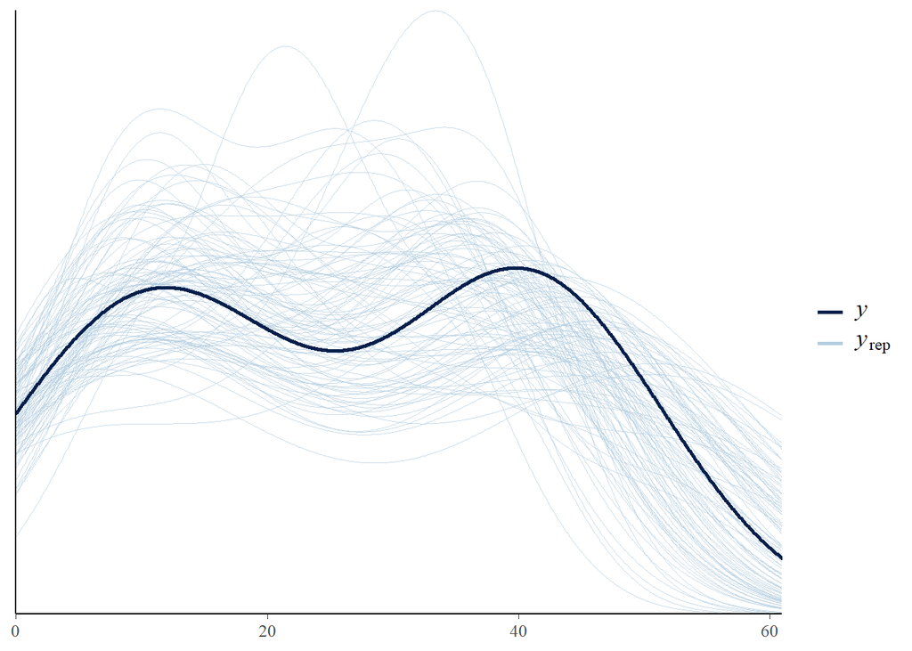

```r
pp_check(fit_exploratory_poisson_awareness_detection, nsamples = 100)
```

```r
summary(fit_exploratory_poisson_awareness_detection)
```

```
##  Family: poisson
##   Links: mu = log
## Formula: counts ~ 1 + awareness * detection
##    Data: data_counts_awareness_detection (Number of observations: 8)
## Samples: 4 chains, each with iter = 10000; warmup = 3000; thin = 1;
##          total post-warmup samples = 28000
##
## Population-Level Effects:
##                             Estimate Est.Error l-95% CI u-95% CI Rhat Bulk_ESS
## Intercept                       3.69      0.11     3.47     3.91 1.00    16994
## awarenessTRUE                   0.01      0.16    -0.29     0.32 1.00    12819
## detectionTRUE                  -1.95      0.31    -2.58    -1.37 1.00     9593
## awarenessTRUE:detectionTRUE     1.00      0.37     0.28     1.74 1.00     9713
##                             Tail_ESS
## Intercept                      18081
## awarenessTRUE                  15074
## detectionTRUE                  12262
## awarenessTRUE:detectionTRUE    12885
##
## Samples were drawn using sampling(NUTS). For each parameter, Bulk_ESS
## and Tail_ESS are effective sample size measures, and Rhat is the potential
## scale reduction factor on split chains (at convergence, Rhat = 1).
```

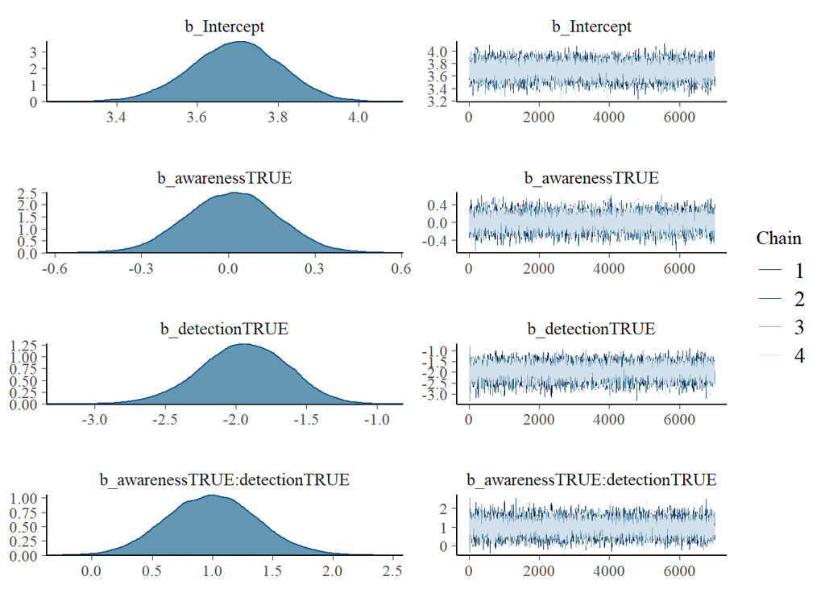

```r
plot(fit_exploratory_poisson_awareness_detection, ask = FALSE)
```

### Check informativeness of prior

Using Gelman’s (2019) simple heuristic: For each parameter, compare the posterior sd to the prior sd. If the posterior sd for any parameter is more than 0.1 times the prior sd, then note that the prior was informative.

```r
check_prior(fit_exploratory_poisson_awareness_detection) %>%
  kable() %>%
  kable_styling(bootstrap_options = c("striped", "hover", "condensed"),
                full_width = FALSE)
```

| Parameter | Prior_Quality |
| --- | --- |
| b_Intercept | uninformative |
| b_awarenessTRUE | uninformative |
| b_detectionTRUE | uninformative |
| b_awarenessTRUE.detectionTRUE | uninformative |

### Interpret posteriors

sjPlot doesn’t behave well with these variable names for some reason. From top to bottom, the parameters are awareness, detection, and awareness*detection.

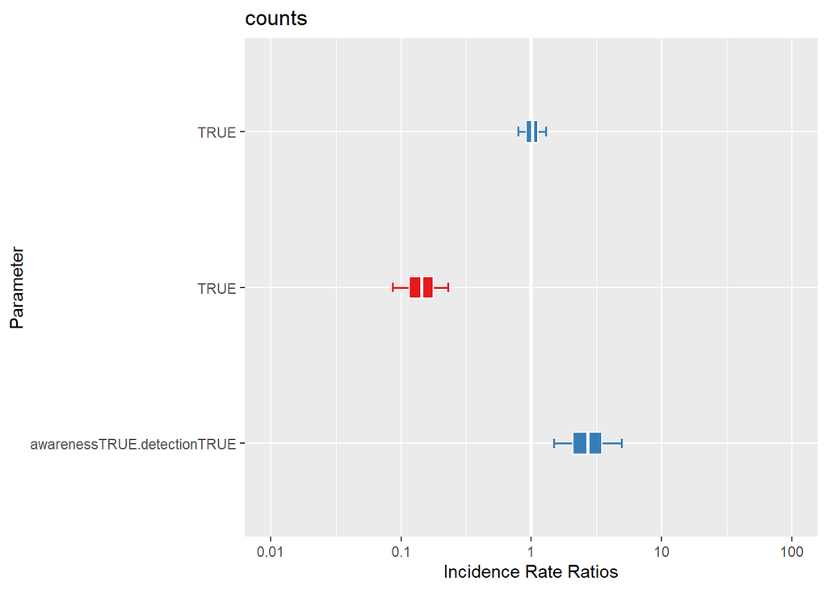

```r
plot_model(fit_exploratory_poisson_awareness_detection) + xlab("Parameter")
```

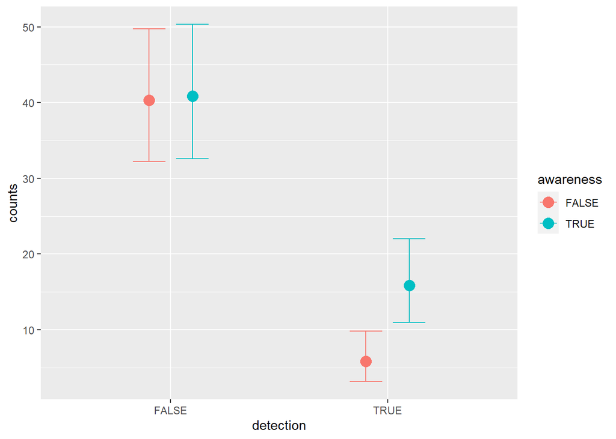

```r
plot(conditional_effects(fit_exploratory_poisson_awareness_detection,
                         effects = "detection:awareness"), ask = FALSE)
```

#### Parameter estimates

```r
# posterior draws for parameters (for results table)
draws_awareness_detection <- posterior_samples(fit_exploratory_poisson_awareness_detection) %>%
  dplyr::select(awarenessTRUE = b_awarenessTRUE,
                detectionTRUE = b_detectionTRUE,
                interaction   = `b_awarenessTRUE:detectionTRUE`) %>%
  mutate(effect_awareness_increases_detection = awarenessTRUE + interaction)

estimates_awareness_detection <-
  full_join(as_tibble(map_estimate(draws_awareness_detection)),
            as_tibble(bayestestR::hdi(draws_awareness_detection, ci = .95)),
          by = "Parameter") %>%
  # exponentiate the log IRR values to IRR
  mutate_if(is.numeric, exp) %>%
  full_join(draws_awareness_detection %>%
              gather(Parameter, value) %>%
              group_by(Parameter) %>%
              summarize(pd = mean(exp(value) > 1)) %>%
              mutate(p = pd_to_p(pd, direction = "one-sided")) %>%
              ungroup() %>%
              select(Parameter, p),
            by = "Parameter") %>%
  dplyr::select(Parameter, incidence_rate_ratio_MAP = MAP_Estimate, CI_95_lower = CI_low, CI_95_upper = CI_high, p)
  # convert from odds to probability
  # mutate_if(is.numeric, function(x){x/(1+x)})

# table
estimates_awareness_detection %>%
  mutate_at(vars("incidence_rate_ratio_MAP", "CI_95_lower", "CI_95_upper"), round, digits = 2) %>%
  kable() %>%
  kable_styling(bootstrap_options = c("striped", "hover", "condensed"),
                full_width = FALSE)
```

| Parameter | incidence_rate_ratio_MAP | CI_95_lower | CI_95_upper | p |
| --- | --- | --- | --- | --- |
| awarenessTRUE | 1.02 | 0.74 | 1.36 | 0.4641429 |
| detectionTRUE | 0.14 | 0.08 | 0.26 | 0.0000000 |
| interaction | 2.71 | 1.33 | 5.75 | 0.0030714 |
| effect_awareness_increases_detection | 2.75 | 1.41 | 5.35 | 0.0007857 |

```r
# hypothesis testing
H4 <- ifelse((estimates_awareness_detection %>% filter(Parameter == "effect_awareness_increases_detection") %>%
                pull(CI_95_lower)) > 1,
              "Accepted", "Rejected")

comparison_string_awareness_detection <-
  paste0("Individuals who were aware of the concept of Deepfakes prior to participating in the study were ",
         estimates_awareness_detection %>%
           filter(Parameter == "effect_awareness_increases_detection") %>%
           pull(incidence_rate_ratio_MAP) %>%
           round(1),
         " times more likely to detect that they had been shown a deepfake than those who were not aware of the concept (Incidence Rate Ratio = ",
         estimates_awareness_detection %>%
           filter(Parameter == "effect_awareness_increases_detection") %>%
           pull(incidence_rate_ratio_MAP) %>%
           round(2),
         ", 95% CI [",
         estimates_awareness_detection %>%
           filter(Parameter == "effect_awareness_increases_detection") %>%
           pull(CI_95_lower) %>%
           round(2),
         ", ",
         estimates_awareness_detection %>%
           filter(Parameter == "effect_awareness_increases_detection") %>%
           pull(CI_95_upper) %>%
           round(2),
         "])")
```

*H4*

Using the subset of participants who were in the Deepfake condition, we calculated counts for each of the combinations of the Deepfake concept check and Deepfake detection questions (e.g., awareness = TRUE & detection = TRUE, awareness = TRUE & detection = FALSE, etc.). We will then use a Bayesian Poisson model to estimate a 95% Credible Interval around the effect’s Incidence Rate Ratio. A Credible Interval whose lower bound is > 1 will be considered evidence in support of this hypothesis. Estimated marginal predicted probabilities will also be reported.

- Result: Accepted
- Individuals who were aware of the concept of Deepfakes prior to participating in the study were 2.8 times more likely to detect that they had been shown a deepfake than those who were not aware of the concept (Incidence Rate Ratio = 2.75, 95% CI [1.41, 5.35])

#### Predicted probabilities

```r
posterior_predictions_awareness_detection <-
  tibble(experiment = c("5", "6"),
         awareness = c("TRUE", "FALSE"),
         detection = c("TRUE", "FALSE")) %>%
  data_grid(experiment, awareness, detection) %>%
  add_predicted_draws(model = fit_exploratory_poisson_awareness_detection, re_formula = NULL) %>%
  rename(predicted_count = .prediction) %>%
  left_join(total_counts_awareness_detection, by = "experiment") %>%
  mutate(predicted_probabiity = predicted_count/total) %>%
  ungroup() %>%
  dplyr::select(experiment, awareness, detection, predicted_count, predicted_probabiity)


posterior_predictions_awareness_detection_aT_dT <- posterior_predictions_awareness_detection %>%
  filter(awareness == "TRUE" & detection == "TRUE")
posterior_predictions_awareness_detection_aT_dF <- posterior_predictions_awareness_detection %>%
  filter(awareness == "TRUE" & detection == "FALSE")
posterior_predictions_awareness_detection_aF_dT <- posterior_predictions_awareness_detection %>%
  filter(awareness == "FALSE" & detection == "TRUE")
posterior_predictions_awareness_detection_aF_dF <- posterior_predictions_awareness_detection %>%
  filter(awareness == "FALSE" & detection == "FALSE")


results_detection_probabilities <-
  rbind(
    bind_cols(as_tibble(map_estimate(posterior_predictions_awareness_detection_aT_dT$predicted_probabiity)),
              as_tibble(bayestestR::hdi(posterior_predictions_awareness_detection_aT_dT$predicted_probabiity,
                                        ci = .95))) %>%
      mutate(awareness = "TRUE", detection = "TRUE"),
    bind_cols(as_tibble(map_estimate(posterior_predictions_awareness_detection_aT_dF$predicted_probabiity)),
              as_tibble(bayestestR::hdi(posterior_predictions_awareness_detection_aT_dF$predicted_probabiity,
                                        ci = .95))) %>%
      mutate(awareness = "TRUE", detection = "FALSE"),
    bind_cols(as_tibble(map_estimate(posterior_predictions_awareness_detection_aF_dT$predicted_probabiity)),
              as_tibble(bayestestR::hdi(posterior_predictions_awareness_detection_aF_dT$predicted_probabiity,
                                        ci = .95))) %>%
      mutate(awareness = "FALSE", detection = "TRUE"),
    bind_cols(as_tibble(map_estimate(posterior_predictions_awareness_detection_aF_dF$predicted_probabiity)),
              as_tibble(bayestestR::hdi(posterior_predictions_awareness_detection_aF_dF$predicted_probabiity,
                                        ci = .95))) %>%
      mutate(awareness = "FALSE", detection = "FALSE")
  ) %>%
  dplyr::select(awareness, detection, detection_probability_MAP = value,
                CI_95_lower = CI_low, CI_95_upper = CI_high) %>%
  mutate_if(is.numeric, round, digits = 3)

results_detection_probabilities %>%
  kable() %>%
  kable_styling(bootstrap_options = c("striped", "hover", "condensed"),
                full_width = FALSE)
```

| awareness | detection | detection_probability_MAP | CI_95_lower | CI_95_upper |
| --- | --- | --- | --- | --- |
| TRUE | TRUE | 0.136 | 0.077 | 0.260 |
| TRUE | FALSE | 0.369 | 0.252 | 0.544 |
| FALSE | TRUE | 0.058 | 0.010 | 0.115 |
| FALSE | FALSE | 0.379 | 0.240 | 0.534 |

- Probability of detecting deepfake if unaware: 0.058
- Probability of detecting deepfake if aware: 0.136

# RQ5: Does prior awareness of the concept of Deepfakes make people immune to their influence?

Subset who received deepfaked videos and were aware of the concept prior to the experiment. Same Bayesian multilevel models as employed above, using only source_valence as IV, i.e., to detect whether learning effects are credibly non-zero in this subset.

## Sample sizes

```r
data_aware_subset_n <- data_after_exclusions %>%
  filter(experiment_condition == "deepfaked" & !is.na(deepfake_awareness_open_recoded)) %>%
  count(deepfake_awareness_open_recoded) %>%
  mutate(proportion = round(n/sum(n), 2)) %>%
  arrange(desc(proportion))

data_aware_subset_n %>%
  kable() %>%
  kable_styling(bootstrap_options = c("striped", "hover", "condensed"),
                full_width = FALSE)
```

| deepfake_awareness_open_recoded | n | proportion |
| --- | --- | --- |
| TRUE | 114 | 0.55 |
| FALSE | 93 | 0.45 |

```r
data_aware_subset <- data_after_exclusions %>%
  filter(experiment_condition == "deepfaked" & deepfake_awareness_open_recoded == TRUE)
```

## Self-reported evaluations

### Fit model

```r
fit_exploratory_selfreport_deepfaked_aware <-
  brm(formula = mean_self_reported_evaluation ~ source_valence + (1 | experiment),
      family  = gaussian(),
      data    = data_aware_subset,
      file    = "models/fit_exploratory_selfreport_deepfaked_aware",
      prior   = prior(normal(0, 10)),
      iter    = 10000,
      warmup  = 3000,
      control = list(adapt_delta = 0.99),  # to avoid divergent transitions
      chains  = 4,
      cores   = parallel::detectCores())
```

### Inspect convergence

```r
summary(fit_exploratory_selfreport_deepfaked_aware)
```

```
##  Family: gaussian
##   Links: mu = identity; sigma = identity
## Formula: mean_self_reported_evaluation ~ source_valence + (1 | experiment)
##    Data: data_aware_subset (Number of observations: 114)
## Samples: 4 chains, each with iter = 10000; warmup = 3000; thin = 1;
##          total post-warmup samples = 28000
##
## Group-Level Effects:
## ~experiment (Number of levels: 2)
##               Estimate Est.Error l-95% CI u-95% CI Rhat Bulk_ESS Tail_ESS
## sd(Intercept)     0.79      1.03     0.01     3.68 1.00     4367     5691
##
## Population-Level Effects:
##                        Estimate Est.Error l-95% CI u-95% CI Rhat Bulk_ESS
## Intercept                 -1.59      0.70    -3.10    -0.02 1.00     5130
## source_valencepositive     3.07      0.21     2.67     3.48 1.00    16036
##                        Tail_ESS
## Intercept                  3882
## source_valencepositive    15729
##
## Family Specific Parameters:
##       Estimate Est.Error l-95% CI u-95% CI Rhat Bulk_ESS Tail_ESS
## sigma     1.07      0.07     0.94     1.23 1.00    13710     8240
##
## Samples were drawn using sampling(NUTS). For each parameter, Bulk_ESS
## and Tail_ESS are effective sample size measures, and Rhat is the potential
## scale reduction factor on split chains (at convergence, Rhat = 1).
```

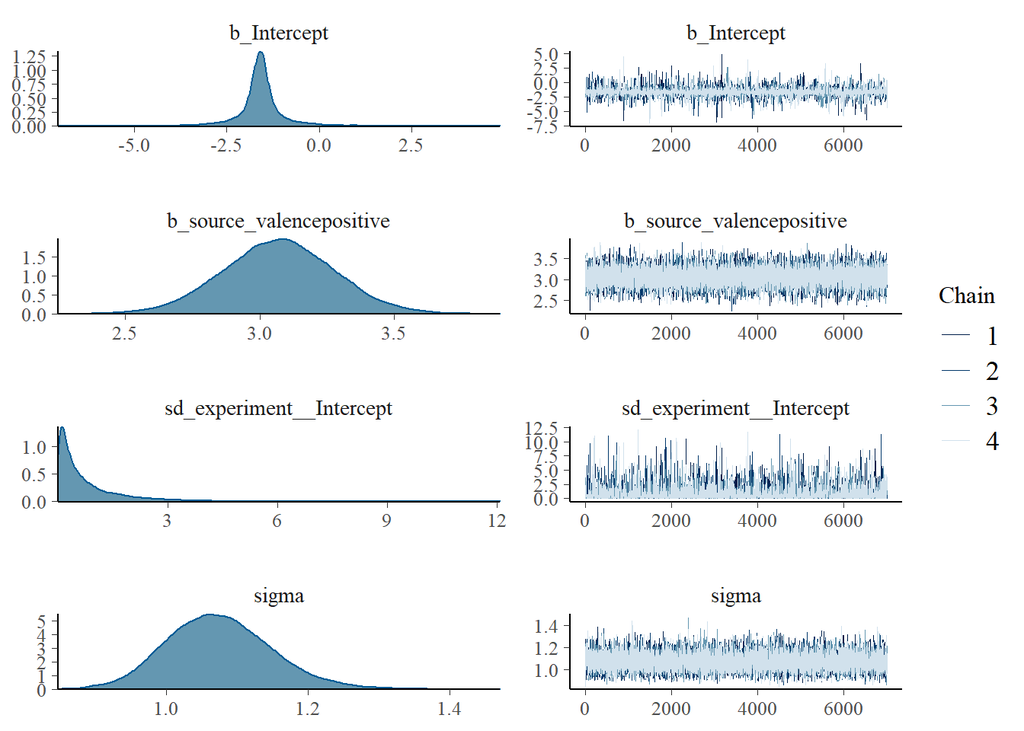

```r
plot(fit_exploratory_selfreport_deepfaked_aware, ask = FALSE)
```

### Check informativeness of prior

Using Gelman’s (2019) simple heuristic: For each parameter, compare the posterior sd to the prior sd. If the posterior sd for any parameter is more than 0.1 times the prior sd, then note that the prior was informative.

```r
check_prior(fit_exploratory_selfreport_deepfaked_aware) %>%
  kable() %>%
  kable_styling(bootstrap_options = c("striped", "hover", "condensed"),
                full_width = FALSE)
```

| Parameter | Prior_Quality |
| --- | --- |
| b_Intercept | uninformative |
| b_source_valencepositive | uninformative |

### Interpret posteriors

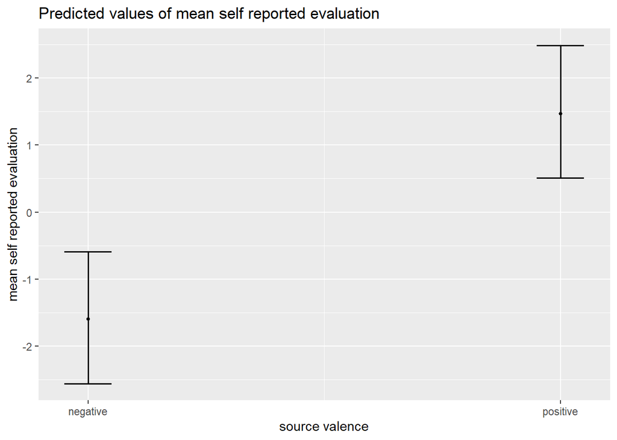

```r
#plot_model(fit_exploratory_selfreport_deepfaked_aware)
plot_model(fit_exploratory_selfreport_deepfaked_aware, type = "pred", terms = "source_valence")
```

```r
# results table
draws_sr_deepfaked_aware <-
  select(spread_draws(fit_exploratory_selfreport_deepfaked_aware, b_source_valencepositive), b_source_valencepositive) %>%
  rename(effect_deepfaked_aware = b_source_valencepositive)

estimates_sr_deepfaked_aware <-
  map_estimate(draws_sr_deepfaked_aware) %>%
  full_join(bayestestR::hdi(draws_sr_deepfaked_aware, ci = .95) %>%
              rename(CI_95_lower = CI_low,
                     CI_95_upper = CI_high) %>%
              as_tibble(),
            by = "Parameter") %>%
  full_join(bayestestR::hdi(draws_sr_deepfaked_aware, ci = .90) %>%
              as_tibble() %>%
              rename(CI_90_lower = CI_low,
                     CI_90_upper = CI_high),
            by = "Parameter") %>%
  full_join(draws_sr_deepfaked_aware %>%
              gather(Parameter, value) %>%
              group_by(Parameter) %>%
              summarize(pd = mean(value > 0)) %>%
              mutate(p = pd_to_p(pd, direction = "one-sided")) %>%
              ungroup() %>%
              select(Parameter, p),
            by = "Parameter") %>%
  select(Parameter, MAP_Estimate, CI_95_lower, CI_95_upper,
         CI_90_lower, CI_90_upper, p)

bind_rows(filter(estimates_sr, Parameter %in% c("effect_deepfaked")),
          estimates_sr_deepfaked_aware) %>%
  mutate_at(.vars = c("MAP_Estimate", "CI_95_lower", "CI_95_upper", "CI_90_lower", "CI_90_upper"), round, digits = 2) %>%
  kable() %>%
  kable_styling(bootstrap_options = c("striped", "hover", "condensed"),
                full_width = FALSE)
```

| Parameter | MAP_Estimate | CI_95_lower | CI_95_upper | CI_90_lower | CI_90_upper | p |
| --- | --- | --- | --- | --- | --- | --- |
| effect_deepfaked | 2.71 | 2.53 | 2.88 | 2.57 | 2.86 | 0 |
| effect_deepfaked_aware | 3.08 | 2.66 | 3.48 | 2.73 | 3.41 | 0 |

```r
# hypothesis testing
H5a <- ifelse((estimates_sr_deepfaked_aware %>% filter(Parameter == "effect_deepfaked_aware") %>%
                 pull(CI_95_lower)) > 0,
              "Accepted", "Rejected")
```

*H5a*

In the subset of participants who were shown a Deepfaked video and reported being aware of the concept of Deepfaking prior to participating in the experiment, the content of the Deepfaked videos (i.e., Source Valence) will influence participants’ self-reported evaluations.

- Result: Accepted

## Implicit

### Fit model

```r
fit_exploratory_implicit_deepfaked_aware <-
  brm(formula = IAT_D2 ~ source_valence + (1 | experiment),
      family  = gaussian(),
      data    = data_aware_subset,
      file    = "models/fit_exploratory_implicit_deepfaked_aware",
      prior   = prior(normal(0, 10)),
      iter    = 10000,
      warmup  = 3000,
      control = list(adapt_delta = 0.99),  # to avoid divergent transitions
      chains  = 4,
      cores   = parallel::detectCores())
```

### Inspect convergence

```r
summary(fit_exploratory_implicit_deepfaked_aware)
```

```
##  Family: gaussian
##   Links: mu = identity; sigma = identity
## Formula: IAT_D2 ~ source_valence + (1 | experiment)
##    Data: data_aware_subset (Number of observations: 114)
## Samples: 4 chains, each with iter = 10000; warmup = 3000; thin = 1;
##          total post-warmup samples = 28000
##
## Group-Level Effects:
## ~experiment (Number of levels: 2)
##               Estimate Est.Error l-95% CI u-95% CI Rhat Bulk_ESS Tail_ESS
## sd(Intercept)     0.74      1.01     0.01     3.43 1.00     4854     7905
##
## Population-Level Effects:
##                        Estimate Est.Error l-95% CI u-95% CI Rhat Bulk_ESS
## Intercept                 -0.08      0.65    -1.53     1.33 1.00     7124
## source_valencepositive     1.39      0.19     1.03     1.76 1.00    16343
##                        Tail_ESS
## Intercept                  6237
## source_valencepositive    15800
##
## Family Specific Parameters:
##       Estimate Est.Error l-95% CI u-95% CI Rhat Bulk_ESS Tail_ESS
## sigma     0.99      0.07     0.87     1.13 1.00    15629    14108
##
## Samples were drawn using sampling(NUTS). For each parameter, Bulk_ESS
## and Tail_ESS are effective sample size measures, and Rhat is the potential
## scale reduction factor on split chains (at convergence, Rhat = 1).
```

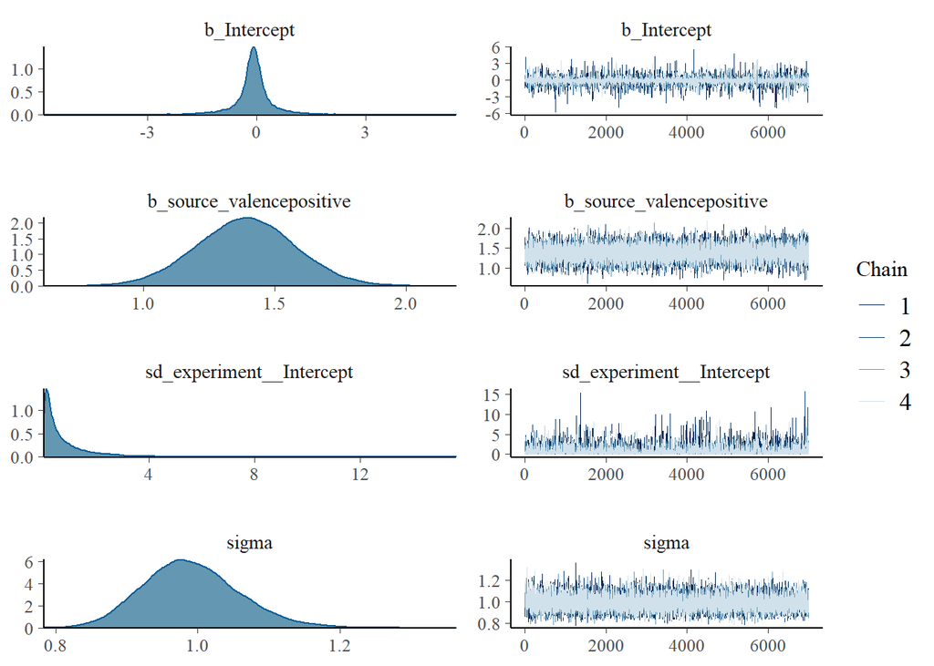

```r
plot(fit_exploratory_implicit_deepfaked_aware, ask = FALSE)
```

### Check informativeness of prior

Using Gelman’s (2019) simple heuristic: For each parameter, compare the posterior sd to the prior sd. If the posterior sd for any parameter is more than 0.1 times the prior sd, then note that the prior was informative.

```r
check_prior(fit_exploratory_implicit_deepfaked_aware) %>%
  kable() %>%
  kable_styling(bootstrap_options = c("striped", "hover", "condensed"),
                full_width = FALSE)
```

| Parameter | Prior_Quality |
| --- | --- |
| b_Intercept | uninformative |
| b_source_valencepositive | uninformative |

### Interpret posteriors

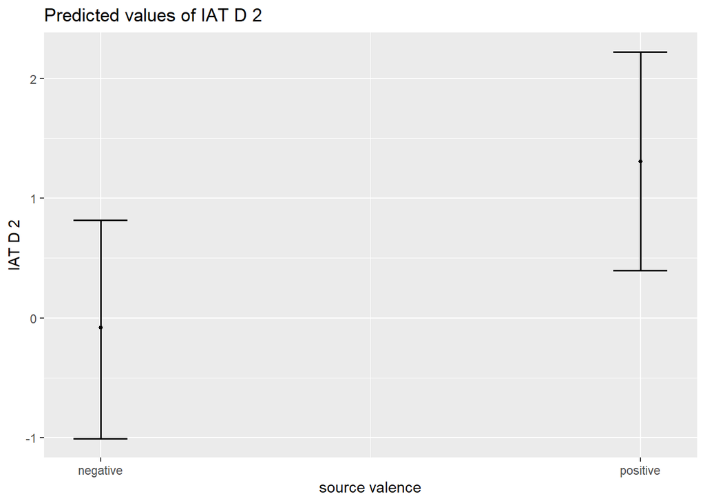

```r
#plot_model(fit_exploratory_implicit_deepfaked_aware)
plot_model(fit_exploratory_implicit_deepfaked_aware, type = "pred", terms = "source_valence")
```

```r
# results table
draws_imp_deepfaked_aware <-
  select(spread_draws(fit_exploratory_implicit_deepfaked_aware, b_source_valencepositive), b_source_valencepositive) %>%
  rename(effect_deepfaked_aware = b_source_valencepositive)

estimates_imp_deepfaked_aware <-
  map_estimate(draws_imp_deepfaked_aware) %>%
  full_join(bayestestR::hdi(draws_imp_deepfaked_aware, ci = .95) %>%
              rename(CI_95_lower = CI_low,
                     CI_95_upper = CI_high) %>%
              as_tibble(),
            by = "Parameter") %>%
  full_join(bayestestR::hdi(draws_imp_deepfaked_aware, ci = .90) %>%
              as_tibble() %>%
              rename(CI_90_lower = CI_low,
                     CI_90_upper = CI_high),
            by = "Parameter") %>%
  full_join(draws_imp_deepfaked_aware %>%
              gather(Parameter, value) %>%
              group_by(Parameter) %>%
              summarize(pd = mean(value > 0)) %>%
              mutate(p = pd_to_p(pd, direction = "one-sided")) %>%
              ungroup() %>%
              select(Parameter, p),
            by = "Parameter") %>%
  select(Parameter, MAP_Estimate, CI_95_lower, CI_95_upper,
         CI_90_lower, CI_90_upper, p)

bind_rows(filter(estimates_imp, Parameter %in% c("effect_deepfaked")),
          estimates_imp_deepfaked_aware) %>%
  mutate_at(.vars = c("MAP_Estimate", "CI_95_lower", "CI_95_upper", "CI_90_lower", "CI_90_upper"), round, digits = 2) %>%
  kable() %>%
  kable_styling(bootstrap_options = c("striped", "hover", "condensed"),
                full_width = FALSE)
```

| Parameter | MAP_Estimate | CI_95_lower | CI_95_upper | CI_90_lower | CI_90_upper | p |
| --- | --- | --- | --- | --- | --- | --- |
| effect_deepfaked | 1.32 | 1.16 | 1.49 | 1.18 | 1.47 | 0 |
| effect_deepfaked_aware | 1.40 | 1.01 | 1.74 | 1.09 | 1.70 | 0 |

```r
# hypothesis testing
H5b <- ifelse((estimates_imp_deepfaked_aware %>% filter(Parameter == "effect_deepfaked_aware") %>%
                 pull(CI_95_lower)) > 0,
              "Accepted", "Rejected")
```

*H5b*

In the subset of participants who were shown a Deepfaked video and reported being aware of the concept of Deepfaking prior to participating in the experiment, the content of the Deepfaked videos (i.e., Source Valence) will influence participants’ IAT D2 scores.

- Result: Accepted

## Behavioural intentions

### Fit model

```r
fit_exploratory_intentions_deepfaked_aware <-
  brm(formula = mean_intentions ~ source_valence, # no random effect for experiment as only exp 6 assessed intentions
      family  = gaussian(),
      data    = data_aware_subset,
      file    = "models/fit_exploratory_intentions_deepfaked_aware",
      prior   = prior(normal(0, 10)),
      iter    = 10000,
      warmup  = 3000,
      control = list(adapt_delta = 0.99),  # to avoid divergent transitions
      chains  = 4,
      cores   = parallel::detectCores())
```

### Inspect convergence

```r
summary(fit_exploratory_intentions_deepfaked_aware)
```

```
##  Family: gaussian
##   Links: mu = identity; sigma = identity
## Formula: mean_intentions ~ source_valence
##    Data: data_aware_subset (Number of observations: 53)
## Samples: 4 chains, each with iter = 10000; warmup = 3000; thin = 1;
##          total post-warmup samples = 28000
##
## Population-Level Effects:
##                        Estimate Est.Error l-95% CI u-95% CI Rhat Bulk_ESS
## Intercept                 -3.31      0.22    -3.75    -2.88 1.00    19832
## source_valencepositive     3.09      0.29     2.52     3.67 1.00    20123
##                        Tail_ESS
## Intercept                 17302
## source_valencepositive    16661
##
## Family Specific Parameters:
##       Estimate Est.Error l-95% CI u-95% CI Rhat Bulk_ESS Tail_ESS
## sigma     1.04      0.11     0.86     1.28 1.00    17789    16107
##
## Samples were drawn using sampling(NUTS). For each parameter, Bulk_ESS
## and Tail_ESS are effective sample size measures, and Rhat is the potential
## scale reduction factor on split chains (at convergence, Rhat = 1).
```

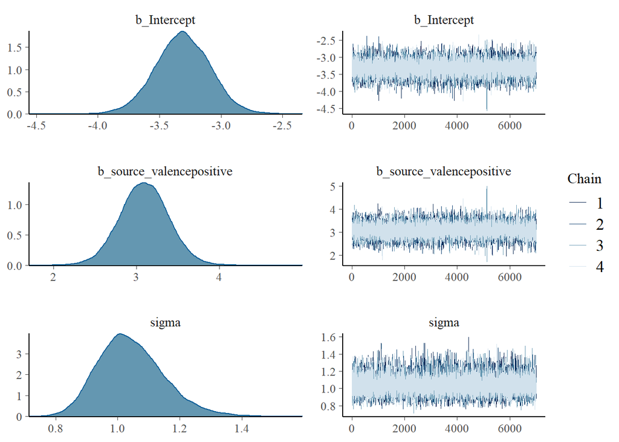

```r
plot(fit_exploratory_intentions_deepfaked_aware, ask = FALSE)
```

### Check informativeness of prior

Using Gelman’s (2019) simple heuristic: For each parameter, compare the posterior sd to the prior sd. If the posterior sd for any parameter is more than 0.1 times the prior sd, then note that the prior was informative.

```r
check_prior(fit_exploratory_intentions_deepfaked_aware) %>%
  kable() %>%
  kable_styling(bootstrap_options = c("striped", "hover", "condensed"),
                full_width = FALSE)
```

| Parameter | Prior_Quality |
| --- | --- |
| b_Intercept | uninformative |
| b_source_valencepositive | uninformative |

### Interpret posteriors

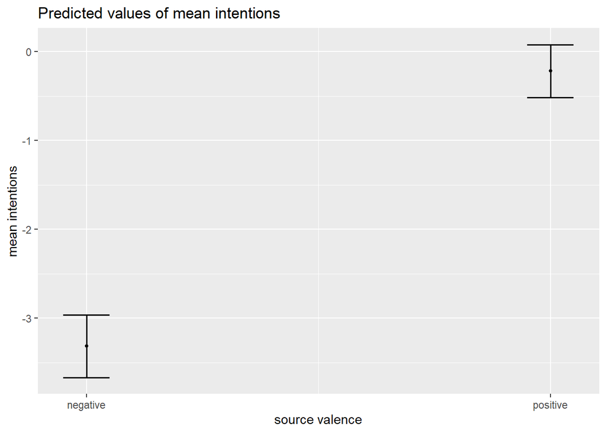

```r
#plot_model(fit_exploratory_intentions_deepfaked_aware)
plot_model(fit_exploratory_intentions_deepfaked_aware, type = "pred", terms = "source_valence")
```

```r
# results table
draws_intentions_deepfaked_aware <-
  select(spread_draws(fit_exploratory_intentions_deepfaked_aware, b_source_valencepositive), b_source_valencepositive) %>%
  rename(effect_deepfaked_aware = b_source_valencepositive)

estimates_intentions_deepfaked_aware <-
  map_estimate(draws_intentions_deepfaked_aware) %>%
  full_join(bayestestR::hdi(draws_intentions_deepfaked_aware, ci = .95) %>%
              rename(CI_95_lower = CI_low,
                     CI_95_upper = CI_high) %>%
              as_tibble(),
            by = "Parameter") %>%
  full_join(bayestestR::hdi(draws_intentions_deepfaked_aware, ci = .90) %>%
              as_tibble() %>%
              rename(CI_90_lower = CI_low,
                     CI_90_upper = CI_high),
            by = "Parameter") %>%
  full_join(draws_intentions_deepfaked_aware %>%
              gather(Parameter, value) %>%
              group_by(Parameter) %>%
              summarize(pd = mean(value > 0)) %>%
              mutate(p = pd_to_p(pd, direction = "one-sided")) %>%
              ungroup() %>%
              select(Parameter, p),
            by = "Parameter") %>%
  select(Parameter, MAP_Estimate, CI_95_lower, CI_95_upper,
         CI_90_lower, CI_90_upper, p)

bind_rows(filter(estimates_intentions, Parameter %in% c("effect_deepfaked")),
          estimates_intentions_deepfaked_aware) %>%
  mutate_at(.vars = c("MAP_Estimate", "CI_95_lower", "CI_95_upper", "CI_90_lower", "CI_90_upper"), round, digits = 2) %>%
  kable() %>%
  kable_styling(bootstrap_options = c("striped", "hover", "condensed"),
                full_width = FALSE)
```

| Parameter | MAP_Estimate | CI_95_lower | CI_95_upper | CI_90_lower | CI_90_upper | p |
| --- | --- | --- | --- | --- | --- | --- |
| effect_deepfaked | 3.06 | 2.67 | 3.45 | 2.75 | 3.41 | 0 |
| effect_deepfaked_aware | 3.09 | 2.52 | 3.67 | 2.61 | 3.56 | 0 |

```r
# hypothesis testing
H5c <- ifelse((estimates_intentions_deepfaked_aware %>% filter(Parameter == "effect_deepfaked_aware") %>%
                 pull(CI_95_lower)) > 0,
              "Accepted", "Rejected")
```

*H5c*

In the subset of participants who were shown a Deepfaked video and reported being aware of the concept of Deepfaking prior to participating in the experiment, the content of the Deepfaked videos (i.e., Source Valence) will influence participants’ behavioral intention scores.

- Result: Accepted

# RQ6: Does detecting that one was exposed to a Deepfake make people immune to its influence?

Subset who received deepfaked videos but also detected them. Same Bayesian multilevel models as employed above, using only source_valence as IV, i.e., to detect whether learning effects are credibly non-zero in this subset.

## Sample sizes

```r
data_detectors_subset_n <- data_after_exclusions %>%
  filter(experiment_condition == "deepfaked" & !is.na(deepfake_detection_open_recoded)) %>%
  count(deepfake_detection_open_recoded) %>%
  mutate(proportion = round(n/sum(n), 2)) %>%
  arrange(desc(proportion))

data_detectors_subset_n %>%
  kable() %>%
  kable_styling(bootstrap_options = c("striped", "hover", "condensed"),
                full_width = FALSE)
```

| deepfake_detection_open_recoded | n | proportion |
| --- | --- | --- |
| FALSE | 273 | 0.73 |
| TRUE | 99 | 0.27 |

```r
data_detectors_subset <- data_after_exclusions %>%
  filter(experiment_condition == "deepfaked" & deepfake_detection_open_recoded == TRUE)
```

## Self-reported evaluations

### Fit model

```r
fit_exploratory_selfreport_deepfaked_detected <-
  brm(formula = mean_self_reported_evaluation ~ source_valence + (1 | experiment),
      family  = gaussian(),
      data    = data_detectors_subset,
      file    = "models/fit_exploratory_selfreport_deepfaked_detected",
      prior   = prior(normal(0, 10)),
      iter    = 10000,
      warmup  = 3000,
      control = list(adapt_delta = 0.99),  # to avoid divergent transitions
      chains  = 4,
      cores   = parallel::detectCores())
```

### Inspect convergence

```r
summary(fit_exploratory_selfreport_deepfaked_detected)
```

```
##  Family: gaussian
##   Links: mu = identity; sigma = identity
## Formula: mean_self_reported_evaluation ~ source_valence + (1 | experiment)
##    Data: data_detectors_subset (Number of observations: 99)
## Samples: 4 chains, each with iter = 10000; warmup = 3000; thin = 1;
##          total post-warmup samples = 28000
##
## Group-Level Effects:
## ~experiment (Number of levels: 3)
##               Estimate Est.Error l-95% CI u-95% CI Rhat Bulk_ESS Tail_ESS
## sd(Intercept)     0.43      0.55     0.01     1.94 1.00     4415     7248
##
## Population-Level Effects:
##                        Estimate Est.Error l-95% CI u-95% CI Rhat Bulk_ESS
## Intercept                 -1.60      0.38    -2.39    -0.84 1.00     6614
## source_valencepositive     2.75      0.24     2.28     3.21 1.00    18013
##                        Tail_ESS
## Intercept                  5394
## source_valencepositive    17433
##
## Family Specific Parameters:
##       Estimate Est.Error l-95% CI u-95% CI Rhat Bulk_ESS Tail_ESS
## sigma     1.17      0.09     1.02     1.36 1.00    17540    16567
##
## Samples were drawn using sampling(NUTS). For each parameter, Bulk_ESS
## and Tail_ESS are effective sample size measures, and Rhat is the potential
## scale reduction factor on split chains (at convergence, Rhat = 1).
```

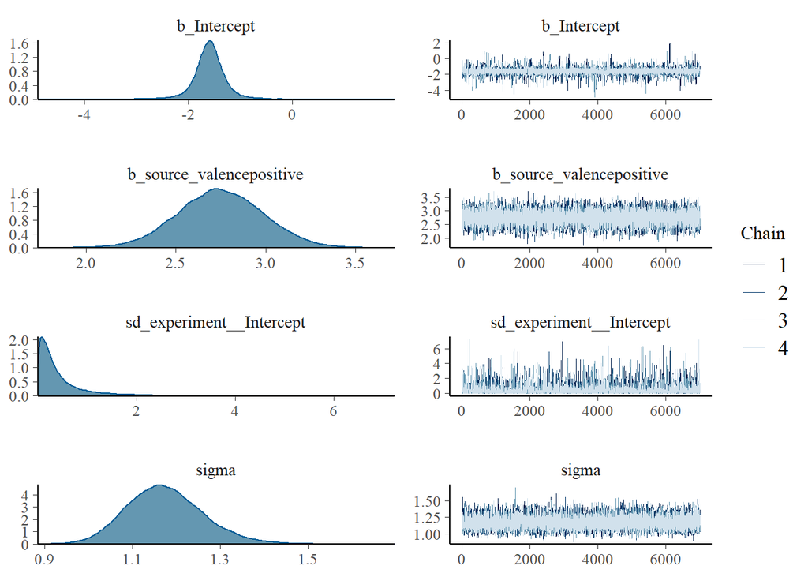

```r
plot(fit_exploratory_selfreport_deepfaked_detected, ask = FALSE)
```

### Check informativeness of prior

Using Gelman’s (2019) simple heuristic: For each parameter, compare the posterior sd to the prior sd. If the posterior sd for any parameter is more than 0.1 times the prior sd, then note that the prior was informative.

```r
check_prior(fit_exploratory_selfreport_deepfaked_detected) %>%
  kable() %>%
  kable_styling(bootstrap_options = c("striped", "hover", "condensed"),
                full_width = FALSE)
```

| Parameter | Prior_Quality |
| --- | --- |
| b_Intercept | uninformative |
| b_source_valencepositive | uninformative |

### Interpret posteriors

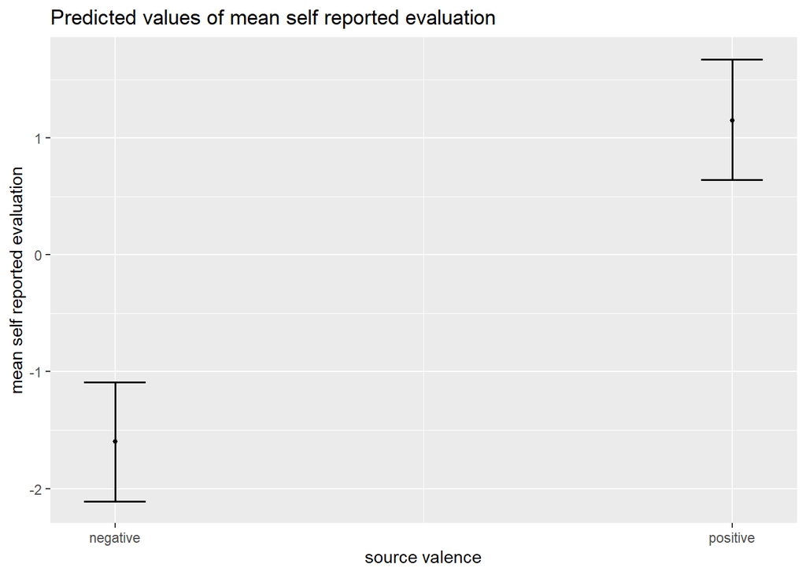

```r
#plot_model(fit_exploratory_selfreport_deepfaked_detected)
plot_model(fit_exploratory_selfreport_deepfaked_detected, type = "pred", terms = "source_valence")
```

```r
# results table
draws_sr_deepfaked_detected <-
  select(spread_draws(fit_exploratory_selfreport_deepfaked_detected, b_source_valencepositive), b_source_valencepositive) %>%
  rename(effect_deepfaked_detected = b_source_valencepositive)

estimates_sr_deepfaked_detected <-
  map_estimate(draws_sr_deepfaked_detected) %>%
  full_join(bayestestR::hdi(draws_sr_deepfaked_detected, ci = .95) %>%
              rename(CI_95_lower = CI_low,
                     CI_95_upper = CI_high) %>%
              as_tibble(),
            by = "Parameter") %>%
  full_join(bayestestR::hdi(draws_sr_deepfaked_detected, ci = .90) %>%
              as_tibble() %>%
              rename(CI_90_lower = CI_low,
                     CI_90_upper = CI_high),
            by = "Parameter") %>%
  full_join(draws_sr_deepfaked_detected %>%
              gather(Parameter, value) %>%
              group_by(Parameter) %>%
              summarize(pd = mean(value > 0)) %>%
              mutate(p = pd_to_p(pd, direction = "one-sided")) %>%
              ungroup() %>%
              select(Parameter, p),
            by = "Parameter") %>%
  select(Parameter, MAP_Estimate, CI_95_lower, CI_95_upper,
         CI_90_lower, CI_90_upper, p)

bind_rows(filter(estimates_sr, Parameter %in% c("effect_deepfaked")),
          estimates_sr_deepfaked_detected) %>%
  mutate_at(.vars = c("MAP_Estimate", "CI_95_lower", "CI_95_upper", "CI_90_lower", "CI_90_upper"), round, digits = 2) %>%
  kable() %>%
  kable_styling(bootstrap_options = c("striped", "hover", "condensed"),
                full_width = FALSE)
```

| Parameter | MAP_Estimate | CI_95_lower | CI_95_upper | CI_90_lower | CI_90_upper | p |
| --- | --- | --- | --- | --- | --- | --- |
| effect_deepfaked | 2.71 | 2.53 | 2.88 | 2.57 | 2.86 | 0 |
| effect_deepfaked_detected | 2.72 | 2.30 | 3.23 | 2.37 | 3.15 | 0 |

```r
# hypothesis testing
H6a <- ifelse((estimates_sr_deepfaked_detected %>% filter(Parameter == "effect_deepfaked_detected") %>%
                 pull(CI_95_lower)) > 0,
              "Accepted", "Rejected")
```

*H6a*

In the subset of participants who were shown a Deepfaked video and accurately detected that the video was Deepfaked, the content of the Deepfaked videos (i.e., Source Valence) will influence participants’ self-reported evaluations.

- Result: Accepted

## Implicit

### Fit model

```r
fit_exploratory_implicit_deepfaked_detected <-
  brm(formula = IAT_D2 ~ source_valence + (1 | experiment),
      family  = gaussian(),
      data    = data_detectors_subset,
      file    = "models/fit_exploratory_implicit_deepfaked_detected",
      prior   = prior(normal(0, 10)),
      iter    = 10000,
      warmup  = 3000,
      control = list(adapt_delta = 0.99),  # to avoid divergent transitions
      chains  = 4,
      cores   = parallel::detectCores())
```

### Inspect convergence

```r
summary(fit_exploratory_implicit_deepfaked_detected)
```

```
##  Family: gaussian
##   Links: mu = identity; sigma = identity
## Formula: IAT_D2 ~ source_valence + (1 | experiment)
##    Data: data_detectors_subset (Number of observations: 99)
## Samples: 4 chains, each with iter = 10000; warmup = 3000; thin = 1;
##          total post-warmup samples = 28000
##
## Group-Level Effects:
## ~experiment (Number of levels: 3)
##               Estimate Est.Error l-95% CI u-95% CI Rhat Bulk_ESS Tail_ESS
## sd(Intercept)     1.06      0.88     0.25     3.31 1.00     5745     8052
##
## Population-Level Effects:
##                        Estimate Est.Error l-95% CI u-95% CI Rhat Bulk_ESS
## Intercept                  0.06      0.68    -1.34     1.47 1.00     6784
## source_valencepositive     1.06      0.19     0.70     1.43 1.00    16138
##                        Tail_ESS
## Intercept                  5738
## source_valencepositive    14822
##
## Family Specific Parameters:
##       Estimate Est.Error l-95% CI u-95% CI Rhat Bulk_ESS Tail_ESS
## sigma     0.91      0.07     0.79     1.05 1.00    16803    15403
##
## Samples were drawn using sampling(NUTS). For each parameter, Bulk_ESS
## and Tail_ESS are effective sample size measures, and Rhat is the potential
## scale reduction factor on split chains (at convergence, Rhat = 1).
```

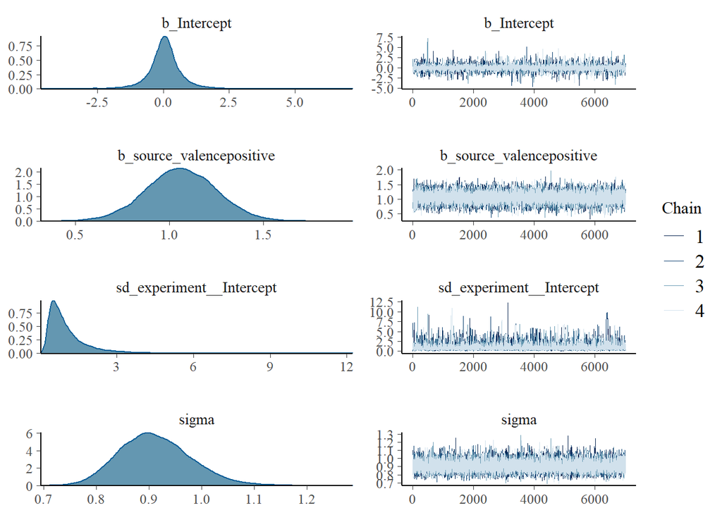

```r
plot(fit_exploratory_implicit_deepfaked_detected, ask = FALSE)
```

### Check informativeness of prior

Using Gelman’s (2019) simple heuristic: For each parameter, compare the posterior sd to the prior sd. If the posterior sd for any parameter is more than 0.1 times the prior sd, then note that the prior was informative.

```r
check_prior(fit_exploratory_implicit_deepfaked_detected) %>%
  kable() %>%
  kable_styling(bootstrap_options = c("striped", "hover", "condensed"),
                full_width = FALSE)
```

| Parameter | Prior_Quality |
| --- | --- |
| b_Intercept | uninformative |
| b_source_valencepositive | uninformative |

### Interpret posteriors

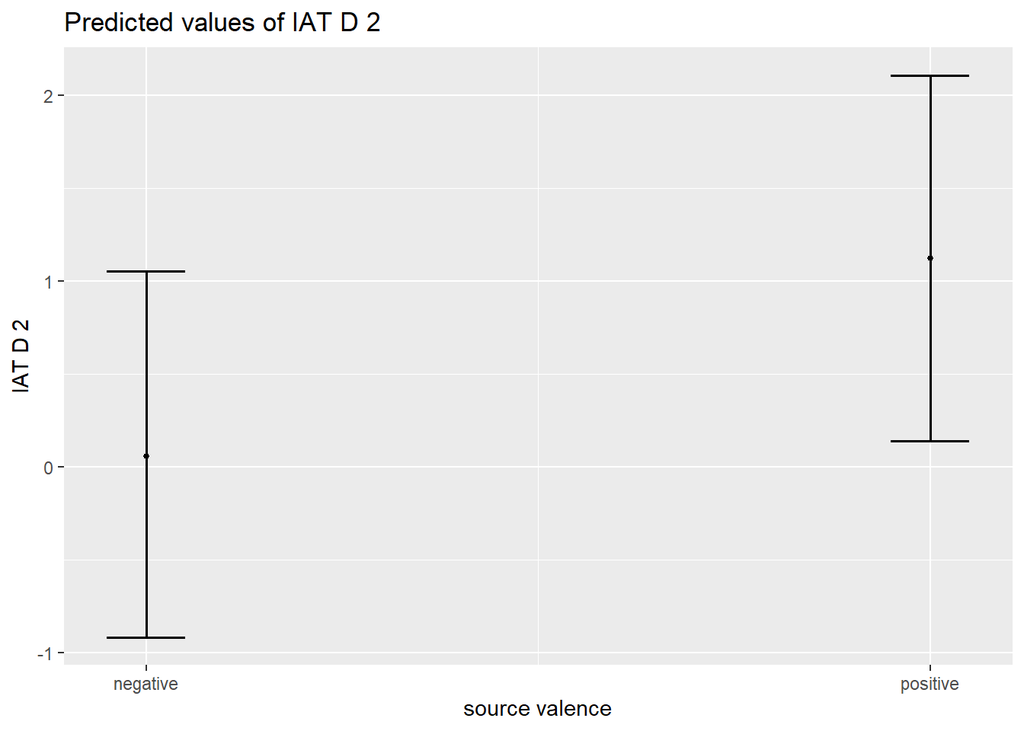

```r
#plot_model(fit_exploratory_implicit_deepfaked_detected)
plot_model(fit_exploratory_implicit_deepfaked_detected, type = "pred", terms = "source_valence")
```

```r
# results table
draws_imp_deepfaked_detected <-
  select(spread_draws(fit_exploratory_implicit_deepfaked_detected, b_source_valencepositive), b_source_valencepositive) %>%
  rename(effect_deepfaked_detected = b_source_valencepositive)

estimates_imp_deepfaked_detected <-
  map_estimate(draws_imp_deepfaked_detected) %>%
  full_join(bayestestR::hdi(draws_imp_deepfaked_detected, ci = .95) %>%
              rename(CI_95_lower = CI_low,
                     CI_95_upper = CI_high) %>%
              as_tibble(),
            by = "Parameter") %>%
  full_join(bayestestR::hdi(draws_imp_deepfaked_detected, ci = .90) %>%
              as_tibble() %>%
              rename(CI_90_lower = CI_low,
                     CI_90_upper = CI_high),
            by = "Parameter") %>%
  full_join(draws_imp_deepfaked_detected %>%
              gather(Parameter, value) %>%
              group_by(Parameter) %>%
              summarize(pd = mean(value > 0)) %>%
              mutate(p = pd_to_p(pd, direction = "one-sided")) %>%
              ungroup() %>%
              select(Parameter, p),
            by = "Parameter") %>%
  select(Parameter, MAP_Estimate, CI_95_lower, CI_95_upper,
         CI_90_lower, CI_90_upper, p)

bind_rows(filter(estimates_imp, Parameter %in% c("effect_deepfaked")),
          estimates_imp_deepfaked_detected) %>%
  mutate_at(.vars = c("MAP_Estimate", "CI_95_lower", "CI_95_upper", "CI_90_lower", "CI_90_upper"), round, digits = 2) %>%
  kable() %>%
  kable_styling(bootstrap_options = c("striped", "hover", "condensed"),
                full_width = FALSE)
```

| Parameter | MAP_Estimate | CI_95_lower | CI_95_upper | CI_90_lower | CI_90_upper | p |
| --- | --- | --- | --- | --- | --- | --- |
| effect_deepfaked | 1.32 | 1.16 | 1.49 | 1.18 | 1.47 | 0 |
| effect_deepfaked_detected | 1.06 | 0.69 | 1.42 | 0.76 | 1.38 | 0 |

```r
# hypothesis testing
H6b <- ifelse((estimates_imp_deepfaked_detected %>% filter(Parameter == "effect_deepfaked_detected") %>%
                 pull(CI_95_lower)) > 0,
              "Accepted", "Rejected")
```

*H6b*

In the subset of participants who were shown a Deepfaked video and accurately detected that the video was Deepfaked, the content of the Deepfaked videos (i.e., Source Valence) will influence participants’ IAT D2 scores.

- Result: Accepted

## Behavioural intentions

### Fit model

```r
fit_exploratory_intentions_deepfaked_detected <-
  brm(formula = mean_intentions ~ source_valence, # no random effect for experiment as only exp 6 assessed intentions
      family  = gaussian(),
      data    = data_detectors_subset,
      file    = "models/fit_exploratory_intentions_deepfaked_detected",
      prior   = prior(normal(0, 10)),
      iter    = 10000,
      warmup  = 3000,
      control = list(adapt_delta = 0.99),  # to avoid divergent transitions
      chains  = 4,
      cores   = parallel::detectCores())
```

### Inspect convergence

```r
summary(fit_exploratory_intentions_deepfaked_detected)
```

```
##  Family: gaussian
##   Links: mu = identity; sigma = identity
## Formula: mean_intentions ~ source_valence
##    Data: data_detectors_subset (Number of observations: 24)
## Samples: 4 chains, each with iter = 10000; warmup = 3000; thin = 1;
##          total post-warmup samples = 28000
##
## Population-Level Effects:
##                        Estimate Est.Error l-95% CI u-95% CI Rhat Bulk_ESS
## Intercept                 -3.28      0.27    -3.81    -2.75 1.00    18312
## source_valencepositive     2.72      0.41     1.90     3.55 1.00    16911
##                        Tail_ESS
## Intercept                 15035
## source_valencepositive    14186
##
## Family Specific Parameters:
##       Estimate Est.Error l-95% CI u-95% CI Rhat Bulk_ESS Tail_ESS
## sigma     0.99      0.16     0.74     1.35 1.00    16557    16122
##
## Samples were drawn using sampling(NUTS). For each parameter, Bulk_ESS
## and Tail_ESS are effective sample size measures, and Rhat is the potential
## scale reduction factor on split chains (at convergence, Rhat = 1).
```

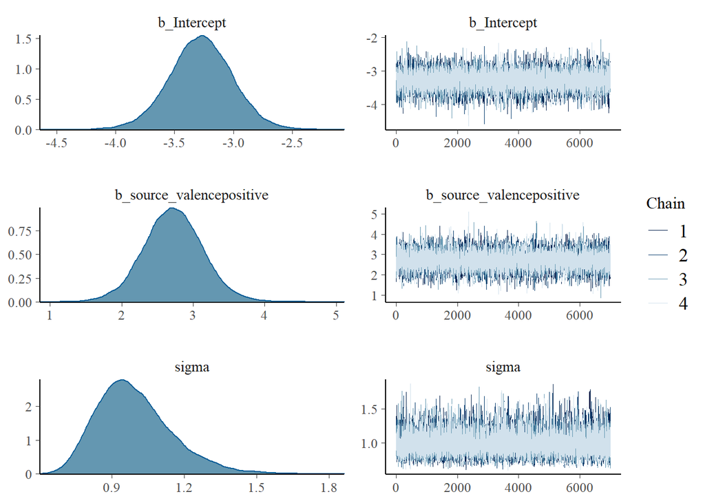

```r
plot(fit_exploratory_intentions_deepfaked_detected, ask = FALSE)
```

### Check informativeness of prior

Using Gelman’s (2019) simple heuristic: For each parameter, compare the posterior sd to the prior sd. If the posterior sd for any parameter is more than 0.1 times the prior sd, then note that the prior was informative.

```r
check_prior(fit_exploratory_intentions_deepfaked_detected) %>%
  kable() %>%
  kable_styling(bootstrap_options = c("striped", "hover", "condensed"),
                full_width = FALSE)
```

| Parameter | Prior_Quality |
| --- | --- |
| b_Intercept | uninformative |
| b_source_valencepositive | uninformative |

### Interpret posteriors

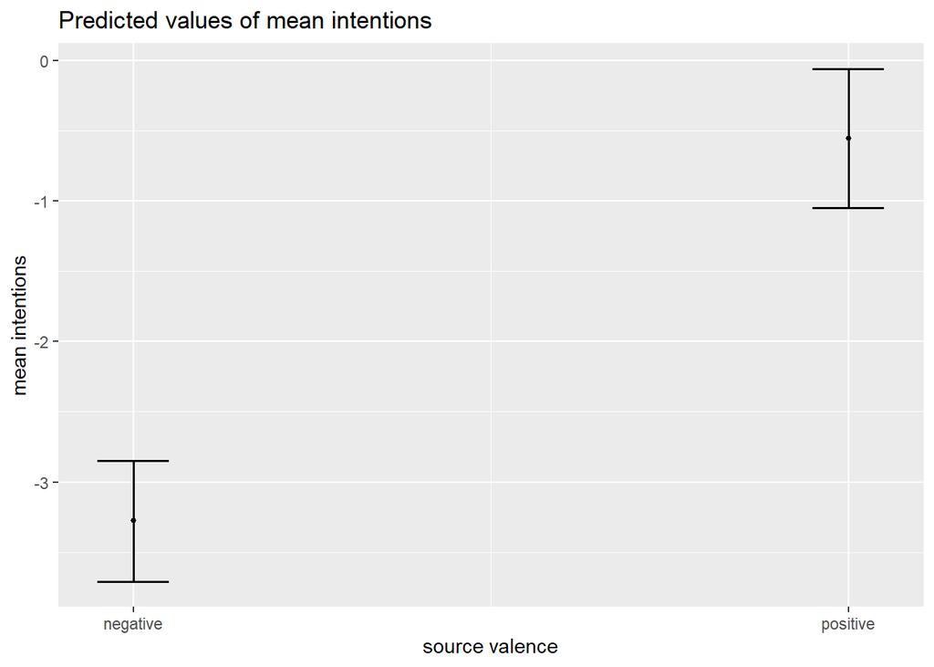

```r
#plot_model(fit_exploratory_intentions_deepfaked_detected)
plot_model(fit_exploratory_intentions_deepfaked_detected, type = "pred", terms = "source_valence")
```

```r
# results table
draws_intentions_deepfaked_detected <-
  select(spread_draws(fit_exploratory_intentions_deepfaked_detected, b_source_valencepositive), b_source_valencepositive) %>%
  rename(effect_deepfaked_detected = b_source_valencepositive)

estimates_intentions_deepfaked_detected <-
  map_estimate(draws_intentions_deepfaked_detected) %>%
  full_join(bayestestR::hdi(draws_intentions_deepfaked_detected, ci = .95) %>%
              rename(CI_95_lower = CI_low,
                     CI_95_upper = CI_high) %>%
              as_tibble(),
            by = "Parameter") %>%
  full_join(bayestestR::hdi(draws_intentions_deepfaked_detected, ci = .90) %>%
              as_tibble() %>%
              rename(CI_90_lower = CI_low,
                     CI_90_upper = CI_high),
            by = "Parameter") %>%
  full_join(draws_intentions_deepfaked_detected %>%
              gather(Parameter, value) %>%
              group_by(Parameter) %>%
              summarize(pd = mean(value > 0)) %>%
              mutate(p = pd_to_p(pd, direction = "one-sided")) %>%
              ungroup() %>%
              select(Parameter, p),
            by = "Parameter") %>%
  select(Parameter, MAP_Estimate, CI_95_lower, CI_95_upper,
         CI_90_lower, CI_90_upper, p)

bind_rows(filter(estimates_intentions, Parameter %in% c("effect_deepfaked")),
          estimates_intentions_deepfaked_detected) %>%
  mutate_at(.vars = c("MAP_Estimate", "CI_95_lower", "CI_95_upper", "CI_90_lower", "CI_90_upper"), round, digits = 2) %>%
  kable() %>%
  kable_styling(bootstrap_options = c("striped", "hover", "condensed"),
                full_width = FALSE)
```

| Parameter | MAP_Estimate | CI_95_lower | CI_95_upper | CI_90_lower | CI_90_upper | p |
| --- | --- | --- | --- | --- | --- | --- |
| effect_deepfaked | 3.06 | 2.67 | 3.45 | 2.75 | 3.41 | 0 |
| effect_deepfaked_detected | 2.70 | 1.91 | 3.55 | 2.03 | 3.38 | 0 |

```r
# hypothesis testing
H6c <- ifelse((estimates_intentions_deepfaked_detected %>% filter(Parameter == "effect_deepfaked_detected") %>%
                 pull(CI_95_lower)) > 0,
              "Accepted", "Rejected")
```

*H6c*

In the subset of participants who were shown a Deepfaked video and accurately detected that the video was Deepfaked, the content of the Deepfaked videos (i.e., Source Valence) will influence participants’ behavioral intention scores.

- Result: Accepted

# RQ7: Does being both aware of the concept of Deepfaking before the study and correcting detecting that content is Deepfaked make you immune to its influence?

Subset who received deepfaked videos, were aware of the concept before the study, and also detected them. Same Bayesian multilevel models as employed above, using only source_valence as IV, i.e., to detect whether learning effects are credibly non-zero in this subset.

## Sample sizes

```r
data_aware_detectors_subset_n <- data_after_exclusions %>%
  filter(experiment_condition == "deepfaked" &
           !is.na(deepfake_detection_open_recoded) &
           !is.na(deepfake_awareness_open_recoded)) %>%
  count(deepfake_detection_open_recoded, deepfake_awareness_open_recoded) %>%
  mutate(proportion = round(n/sum(n), 2)) %>%
  arrange(desc(proportion))

data_aware_detectors_subset_n %>%
  kable() %>%
  kable_styling(bootstrap_options = c("striped", "hover", "condensed"),
                full_width = FALSE)
```

| deepfake_detection_open_recoded | deepfake_awareness_open_recoded | n | proportion |
| --- | --- | --- | --- |
| FALSE | TRUE | 82 | 0.40 |
| FALSE | FALSE | 81 | 0.39 |
| TRUE | TRUE | 32 | 0.15 |
| TRUE | FALSE | 12 | 0.06 |

```r
data_aware_detectors_subset <- data_after_exclusions %>%
  filter(experiment_condition == "deepfaked" & deepfake_detection_open_recoded == TRUE & deepfake_awareness_open_recoded == TRUE)
```

## Self-reported evaluations

### Fit model

```r
fit_exploratory_selfreport_deepfaked_aware_detected <-
  brm(formula = mean_self_reported_evaluation ~ source_valence + (1 | experiment),
      family  = gaussian(),
      data    = data_aware_detectors_subset,
      file    = "models/fit_exploratory_selfreport_deepfaked_aware_detected",
      prior   = prior(normal(0, 10)),
      iter    = 10000,
      warmup  = 3000,
      control = list(adapt_delta = 0.99),  # to avoid divergent transitions
      chains  = 4,
      cores   = parallel::detectCores())
```

### Inspect convergence

```r
summary(fit_exploratory_selfreport_deepfaked_aware_detected)
```

```
##  Family: gaussian
##   Links: mu = identity; sigma = identity
## Formula: mean_self_reported_evaluation ~ source_valence + (1 | experiment)
##    Data: data_aware_detectors_subset (Number of observations: 32)
## Samples: 4 chains, each with iter = 10000; warmup = 3000; thin = 1;
##          total post-warmup samples = 28000
##
## Group-Level Effects:
## ~experiment (Number of levels: 2)
##               Estimate Est.Error l-95% CI u-95% CI Rhat Bulk_ESS Tail_ESS
## sd(Intercept)     0.93      1.07     0.02     3.90 1.00     6435    10705
##
## Population-Level Effects:
##                        Estimate Est.Error l-95% CI u-95% CI Rhat Bulk_ESS
## Intercept                 -1.66      0.80    -3.37     0.02 1.00     8207
## source_valencepositive     3.26      0.48     2.31     4.22 1.00    17817
##                        Tail_ESS
## Intercept                  7798
## source_valencepositive    15747
##
## Family Specific Parameters:
##       Estimate Est.Error l-95% CI u-95% CI Rhat Bulk_ESS Tail_ESS
## sigma     1.34      0.18     1.04     1.76 1.00    17093    15054
##
## Samples were drawn using sampling(NUTS). For each parameter, Bulk_ESS
## and Tail_ESS are effective sample size measures, and Rhat is the potential
## scale reduction factor on split chains (at convergence, Rhat = 1).
```

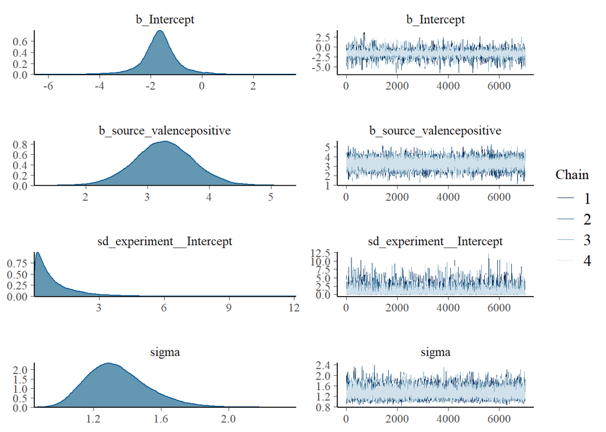

```r
plot(fit_exploratory_selfreport_deepfaked_aware_detected, ask = FALSE)
```

### Check informativeness of prior

Using Gelman’s (2019) simple heuristic: For each parameter, compare the posterior sd to the prior sd. If the posterior sd for any parameter is more than 0.1 times the prior sd, then note that the prior was informative.

```r
check_prior(fit_exploratory_selfreport_deepfaked_aware_detected) %>%
  kable() %>%
  kable_styling(bootstrap_options = c("striped", "hover", "condensed"),
                full_width = FALSE)
```

| Parameter | Prior_Quality |
| --- | --- |
| b_Intercept | uninformative |
| b_source_valencepositive | uninformative |

### Interpret posteriors

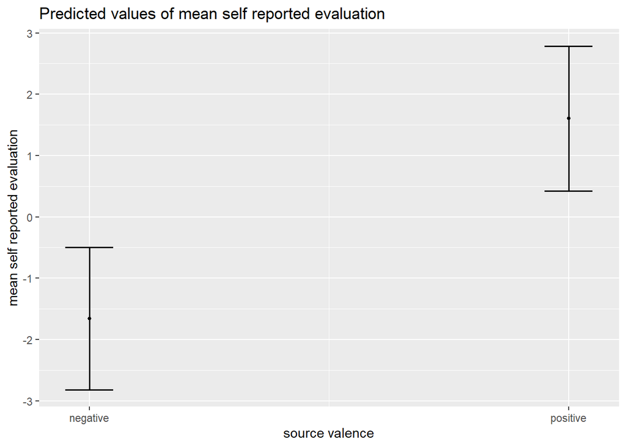

```r
#plot_model(fit_exploratory_selfreport_deepfaked_aware_detected)
plot_model(fit_exploratory_selfreport_deepfaked_aware_detected, type = "pred", terms = "source_valence")
```

```r
# results table
draws_sr_deepfaked_aware_detected <-
  select(spread_draws(fit_exploratory_selfreport_deepfaked_aware_detected, b_source_valencepositive), b_source_valencepositive) %>%
  rename(effect_deepfaked_aware_detected = b_source_valencepositive)

estimates_sr_deepfaked_aware_detected <-
  map_estimate(draws_sr_deepfaked_aware_detected) %>%
  full_join(bayestestR::hdi(draws_sr_deepfaked_aware_detected, ci = .95) %>%
              rename(CI_95_lower = CI_low,
                     CI_95_upper = CI_high) %>%
              as_tibble(),
            by = "Parameter") %>%
  full_join(bayestestR::hdi(draws_sr_deepfaked_aware_detected, ci = .90) %>%
              as_tibble() %>%
              rename(CI_90_lower = CI_low,
                     CI_90_upper = CI_high),
            by = "Parameter") %>%
  full_join(draws_sr_deepfaked_aware_detected %>%
              gather(Parameter, value) %>%
              group_by(Parameter) %>%
              summarize(pd = mean(value > 0)) %>%
              mutate(p = pd_to_p(pd, direction = "one-sided")) %>%
              ungroup() %>%
              select(Parameter, p),
            by = "Parameter") %>%
  select(Parameter, MAP_Estimate, CI_95_lower, CI_95_upper,
         CI_90_lower, CI_90_upper, p)

bind_rows(filter(estimates_sr, Parameter %in% c("effect_deepfaked")),
          estimates_sr_deepfaked_aware_detected) %>%
  mutate_at(.vars = c("MAP_Estimate", "CI_95_lower", "CI_95_upper", "CI_90_lower", "CI_90_upper"), round, digits = 2) %>%
  kable() %>%
  kable_styling(bootstrap_options = c("striped", "hover", "condensed"),
                full_width = FALSE)
```

| Parameter | MAP_Estimate | CI_95_lower | CI_95_upper | CI_90_lower | CI_90_upper | p |
| --- | --- | --- | --- | --- | --- | --- |
| effect_deepfaked | 2.71 | 2.53 | 2.88 | 2.57 | 2.86 | 0 |
| effect_deepfaked_aware_detected | 3.28 | 2.32 | 4.23 | 2.47 | 4.06 | 0 |

```r
# hypothesis testing
H7a <- ifelse((estimates_sr_deepfaked_aware_detected %>% filter(Parameter == "effect_deepfaked_aware_detected") %>%
                 pull(CI_95_lower)) > 0,
              "Accepted", "Rejected")
```

*H7a*

In the subset of participants who were shown a Deepfaked video, reported being aware of the concept of Deepfakes, and accurately detected that the video was Deepfaked, the content of the Deepfaked videos (i.e., Source Valence) will influence participants’ self-reported evaluations.

- Result: Accepted

## Implicit

### Fit model

```r
fit_exploratory_implicit_deepfaked_aware_detected <-
  brm(formula = IAT_D2 ~ source_valence + (1 | experiment),
      family  = gaussian(),
      data    = data_aware_detectors_subset,
      file    = "models/fit_exploratory_implicit_deepfaked_aware_detected",
      prior   = prior(normal(0, 10)),
      iter    = 10000,
      warmup  = 3000,
      control = list(adapt_delta = 0.99),  # to avoid divergent transitions
      chains  = 4,
      cores   = parallel::detectCores())
```

### Inspect convergence

```r
summary(fit_exploratory_implicit_deepfaked_aware_detected)
```

```
##  Family: gaussian
##   Links: mu = identity; sigma = identity
## Formula: IAT_D2 ~ source_valence + (1 | experiment)
##    Data: data_aware_detectors_subset (Number of observations: 32)
## Samples: 4 chains, each with iter = 10000; warmup = 3000; thin = 1;
##          total post-warmup samples = 28000
##
## Group-Level Effects:
## ~experiment (Number of levels: 2)
##               Estimate Est.Error l-95% CI u-95% CI Rhat Bulk_ESS Tail_ESS
## sd(Intercept)     1.33      1.22     0.12     4.54 1.00     6167     6226
##
## Population-Level Effects:
##                        Estimate Est.Error l-95% CI u-95% CI Rhat Bulk_ESS
## Intercept                 -0.21      0.96    -2.27     1.80 1.00     8621
## source_valencepositive     1.23      0.34     0.56     1.89 1.00    15672
##                        Tail_ESS
## Intercept                  9314
## source_valencepositive    14602
##
## Family Specific Parameters:
##       Estimate Est.Error l-95% CI u-95% CI Rhat Bulk_ESS Tail_ESS
## sigma     0.94      0.13     0.73     1.24 1.00    14762    14675
##
## Samples were drawn using sampling(NUTS). For each parameter, Bulk_ESS
## and Tail_ESS are effective sample size measures, and Rhat is the potential
## scale reduction factor on split chains (at convergence, Rhat = 1).
```

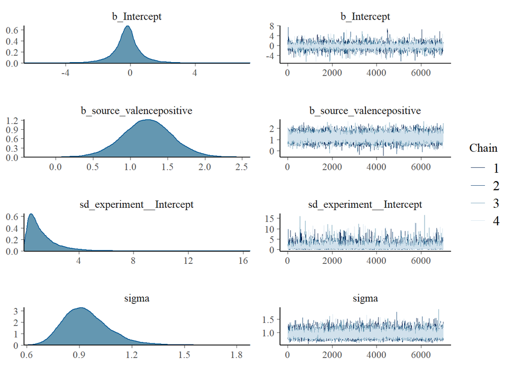

```r
plot(fit_exploratory_implicit_deepfaked_aware_detected, ask = FALSE)
```

### Check informativeness of prior

Using Gelman’s (2019) simple heuristic: For each parameter, compare the posterior sd to the prior sd. If the posterior sd for any parameter is more than 0.1 times the prior sd, then note that the prior was informative.

```r
check_prior(fit_exploratory_implicit_deepfaked_aware_detected) %>%
  kable() %>%
  kable_styling(bootstrap_options = c("striped", "hover", "condensed"),
                full_width = FALSE)
```

| Parameter | Prior_Quality |
| --- | --- |
| b_Intercept | uninformative |
| b_source_valencepositive | uninformative |

### Interpret posteriors

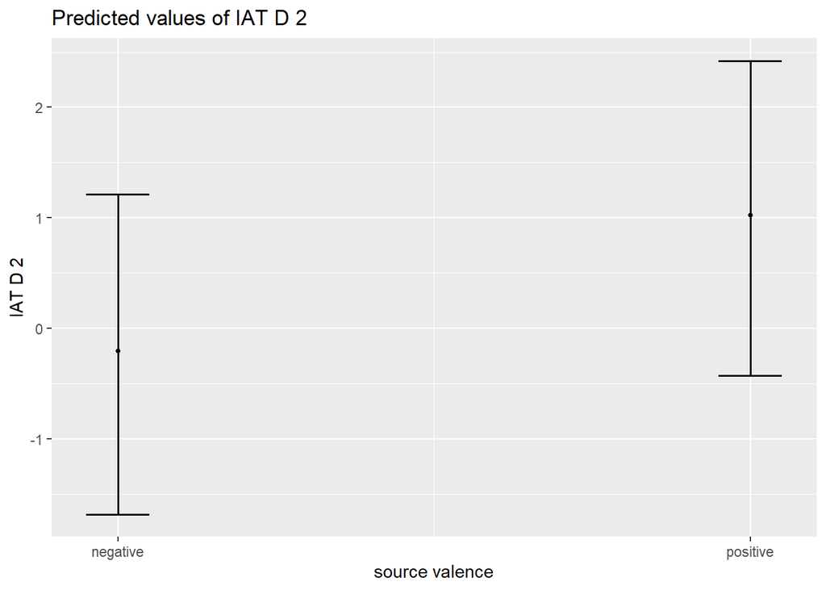

```r
#plot_model(fit_exploratory_implicit_deepfaked_aware_detected)
plot_model(fit_exploratory_implicit_deepfaked_aware_detected, type = "pred", terms = "source_valence")
```

```r
# results table
draws_imp_deepfaked_aware_detected <-
  select(spread_draws(fit_exploratory_implicit_deepfaked_aware_detected, b_source_valencepositive), b_source_valencepositive) %>%
  rename(effect_deepfaked_aware_detected = b_source_valencepositive)

estimates_imp_deepfaked_aware_detected <-
  map_estimate(draws_imp_deepfaked_aware_detected) %>%
  full_join(bayestestR::hdi(draws_imp_deepfaked_aware_detected, ci = .95) %>%
              rename(CI_95_lower = CI_low,
                     CI_95_upper = CI_high) %>%
              as_tibble(),
            by = "Parameter") %>%
  full_join(bayestestR::hdi(draws_imp_deepfaked_aware_detected, ci = .90) %>%
              as_tibble() %>%
              rename(CI_90_lower = CI_low,
                     CI_90_upper = CI_high),
            by = "Parameter") %>%
  full_join(draws_imp_deepfaked_aware_detected %>%
              gather(Parameter, value) %>%
              group_by(Parameter) %>%
              summarize(pd = mean(value > 0)) %>%
              mutate(p = pd_to_p(pd, direction = "one-sided")) %>%
              ungroup() %>%
              select(Parameter, p),
            by = "Parameter") %>%
  select(Parameter, MAP_Estimate, CI_95_lower, CI_95_upper,
         CI_90_lower, CI_90_upper, p)

bind_rows(filter(estimates_imp, Parameter %in% c("effect_deepfaked")),
          estimates_imp_deepfaked_aware_detected) %>%
  mutate_at(.vars = c("MAP_Estimate", "CI_95_lower", "CI_95_upper", "CI_90_lower", "CI_90_upper"), round, digits = 2) %>%
  kable() %>%
  kable_styling(bootstrap_options = c("striped", "hover", "condensed"),
                full_width = FALSE)
```

| Parameter | MAP_Estimate | CI_95_lower | CI_95_upper | CI_90_lower | CI_90_upper | p |
| --- | --- | --- | --- | --- | --- | --- |
| effect_deepfaked | 1.32 | 1.16 | 1.49 | 1.18 | 1.47 | 0.0000000 |
| effect_deepfaked_aware_detected | 1.23 | 0.58 | 1.91 | 0.67 | 1.77 | 0.0004643 |

```r
# hypothesis testing
H7b <- ifelse((estimates_imp_deepfaked_aware_detected %>% filter(Parameter == "effect_deepfaked_aware_detected") %>%
                 pull(CI_95_lower)) > 0,
              "Accepted", "Rejected")
```

*H7b*

In the subset of participants who were shown a Deepfaked video, reported being aware of the concept of Deepfakes, and accurately detected that the video was Deepfaked, the content of the Deepfaked videos (i.e., Source Valence) will influence participants’ IAT D2 scores.

- Result: Accepted

## Behavioural intentions

### Fit model

```r
fit_exploratory_intentions_deepfaked_aware_detected <-
  brm(formula = mean_intentions ~ source_valence, # no random effect for experiment as only exp 6 assessed intentions
      family  = gaussian(),
      data    = data_aware_detectors_subset,
      file    = "models/fit_exploratory_intentions_deepfaked_aware_detected",
      prior   = prior(normal(0, 10)),
      iter    = 10000,
      warmup  = 3000,
      control = list(adapt_delta = 0.99),  # to avoid divergent transitions
      chains  = 4,
      cores   = parallel::detectCores())
```

### Inspect convergence

```r
summary(fit_exploratory_intentions_deepfaked_aware_detected)
```

```
##  Family: gaussian
##   Links: mu = identity; sigma = identity
## Formula: mean_intentions ~ source_valence
##    Data: data_aware_detectors_subset (Number of observations: 17)
## Samples: 4 chains, each with iter = 10000; warmup = 3000; thin = 1;
##          total post-warmup samples = 28000
##
## Population-Level Effects:
##                        Estimate Est.Error l-95% CI u-95% CI Rhat Bulk_ESS
## Intercept                 -3.15      0.37    -3.87    -2.42 1.00    17410
## source_valencepositive     2.46      0.54     1.38     3.53 1.00    15591
##                        Tail_ESS
## Intercept                 14186
## source_valencepositive    14153
##
## Family Specific Parameters:
##       Estimate Est.Error l-95% CI u-95% CI Rhat Bulk_ESS Tail_ESS
## sigma     1.08      0.22     0.75     1.60 1.00    13366    15097
##
## Samples were drawn using sampling(NUTS). For each parameter, Bulk_ESS
## and Tail_ESS are effective sample size measures, and Rhat is the potential
## scale reduction factor on split chains (at convergence, Rhat = 1).
```

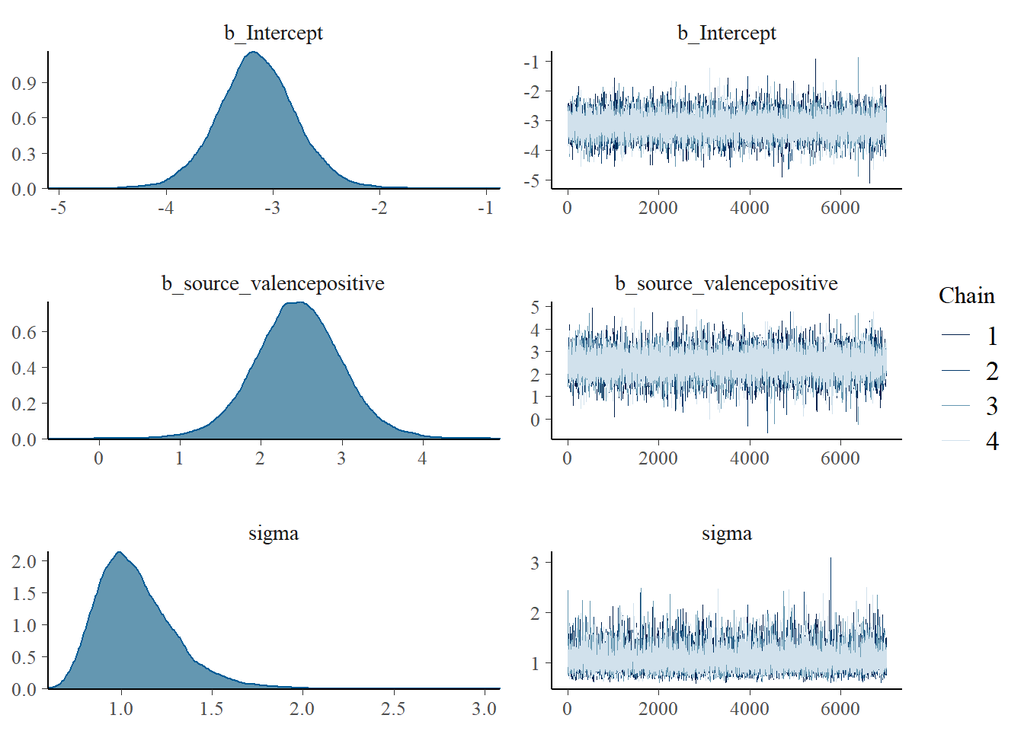

```r
plot(fit_exploratory_intentions_deepfaked_aware_detected, ask = FALSE)
```

### Check informativeness of prior

Using Gelman’s (2019) simple heuristic: For each parameter, compare the posterior sd to the prior sd. If the posterior sd for any parameter is more than 0.1 times the prior sd, then note that the prior was informative.

```r
check_prior(fit_exploratory_intentions_deepfaked_aware_detected) %>%
  kable() %>%
  kable_styling(bootstrap_options = c("striped", "hover", "condensed"),
                full_width = FALSE)
```

| Parameter | Prior_Quality |
| --- | --- |
| b_Intercept | uninformative |
| b_source_valencepositive | uninformative |

### Interpret posteriors

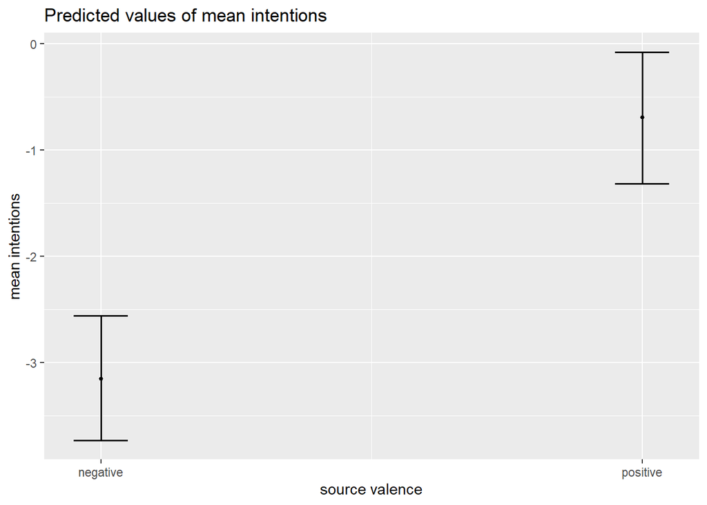

```r
#plot_model(fit_exploratory_intentions_deepfaked_aware_detected)
plot_model(fit_exploratory_intentions_deepfaked_aware_detected, type = "pred", terms = "source_valence")
```

```r
# results table
draws_intentions_deepfaked_aware_detected <-
  select(spread_draws(fit_exploratory_intentions_deepfaked_aware_detected, b_source_valencepositive), b_source_valencepositive) %>%
  rename(effect_deepfaked_aware_detected = b_source_valencepositive)

estimates_intentions_deepfaked_aware_detected <-
  map_estimate(draws_intentions_deepfaked_aware_detected) %>%
  full_join(bayestestR::hdi(draws_intentions_deepfaked_aware_detected, ci = .95) %>%
              rename(CI_95_lower = CI_low,
                     CI_95_upper = CI_high) %>%
              as_tibble(),
            by = "Parameter") %>%
  full_join(bayestestR::hdi(draws_intentions_deepfaked_aware_detected, ci = .90) %>%
              as_tibble() %>%
              rename(CI_90_lower = CI_low,
                     CI_90_upper = CI_high),
            by = "Parameter") %>%
  full_join(draws_intentions_deepfaked_aware_detected %>%
              gather(Parameter, value) %>%
              group_by(Parameter) %>%
              summarize(pd = mean(value > 0)) %>%
              mutate(p = pd_to_p(pd, direction = "one-sided")) %>%
              ungroup() %>%
              select(Parameter, p),
            by = "Parameter") %>%
  select(Parameter, MAP_Estimate, CI_95_lower, CI_95_upper,
         CI_90_lower, CI_90_upper, p)

bind_rows(filter(estimates_intentions, Parameter %in% c("effect_deepfaked")),
          estimates_intentions_deepfaked_aware_detected) %>%
  mutate_at(.vars = c("MAP_Estimate", "CI_95_lower", "CI_95_upper", "CI_90_lower", "CI_90_upper"), round, digits = 2) %>%
  kable() %>%
  kable_styling(bootstrap_options = c("striped", "hover", "condensed"),
                full_width = FALSE)
```

| Parameter | MAP_Estimate | CI_95_lower | CI_95_upper | CI_90_lower | CI_90_upper | p |
| --- | --- | --- | --- | --- | --- | --- |
| effect_deepfaked | 3.06 | 2.67 | 3.45 | 2.75 | 3.41 | 0.0000000 |
| effect_deepfaked_aware_detected | 2.48 | 1.42 | 3.57 | 1.57 | 3.32 | 0.0003929 |

```r
# hypothesis testing
H7c <- ifelse((estimates_intentions_deepfaked_aware_detected %>% filter(Parameter == "effect_deepfaked_aware_detected") %>%
                 pull(CI_95_lower)) > 0,
              "Accepted", "Rejected")
```

*H7c*

In the subset of participants who were shown a Deepfaked video, reported being aware of the concept of Deepfakes, and accurately detected that the video was Deepfaked, the content of the Deepfaked videos (i.e., Source Valence) will influence participants’ behavioral intention scores.

- Result: Accepted

# Summary of hypothesis tests

H1: Establishing first impressions via online video content

- Genuine content can establish self-reported evaluations (Accepted), implicit evaluations (Accepted), and behavioural intentions (Accepted).
- Deepfaked content can establish self-reported evaluations (Accepted), implicit evaluations (Accepted), and behavioural intentions (Accepted).

H2: Are deepfakes just as good as the real thing?

- Deepfakes are non-inferior to genuine content on self-reported evaluations (Accepted), implicit evaluations (Rejected), and behavioural intentions (Accepted).

H3: How good are people at detecting whether content is genuine or Deepfaked?

Whole sample

```r
classifications %>%
  kable() %>%
  kable_styling(bootstrap_options = c("striped", "hover", "condensed"),
                full_width = FALSE)
```

| variable | observed | ci_lower | ci_upper |
| --- | --- | --- | --- |
| balanced_accuracy | 0.59 | 0.56 | 0.62 |
| false_negative_rate | 0.73 | 0.69 | 0.78 |
| false_positive_rate | 0.08 | 0.04 | 0.12 |
| informedness | 0.19 | 0.13 | 0.25 |

Those who were aware of the concept prior to the study

```r
classifications_subset %>%
  kable() %>%
  kable_styling(bootstrap_options = c("striped", "hover", "condensed"),
                full_width = FALSE)
```

| variable | observed | ci_lower | ci_upper |
| --- | --- | --- | --- |
| balanced_accuracy | 0.59 | 0.54 | 0.64 |
| false_negative_rate | 0.72 | 0.64 | 0.80 |
| false_positive_rate | 0.09 | 0.05 | 0.15 |
| informedness | 0.19 | 0.08 | 0.28 |

H4: Does prior awareness of the concept of Deepfakes make people better at detecting them?

- Percent aware of the concept of Deepfakes: 53.5
- Of those exposed to a Deepfake, Individuals who were aware of the concept of Deepfakes prior to participating in the study were 2.8 times more likely to detect that they had been shown a deepfake than those who were not aware of the concept (Incidence Rate Ratio = 2.75, 95% CI [1.41, 5.35]), Accepted.

H5-7: Does being aware of the concept, detecitng the deepfake, or both make you immune to a Deepfake?

- H5: Evaluative learning effects found in the subset who were shown Deepfakes and were aware of the concept, on self-reports (Accepted), implicit measure (Accepted) and behavioural intentions (Accepted).
- H6: Evaluative learning effects found in the subset who were shown Deepfakes and detected them, on self-reports (Accepted), implicit measure (Accepted) and behavioural intentions (Accepted).
- H6: Evaluative learning effects found in the subset who were shown Deepfakes, were aware of the concept, and detected them, on self-reports (Accepted), implicit measure (Accepted) and behavioural intentions (Accepted).

# Illustrative models

For the sake of conveying points in the summary manuscript, e.g., that deepfakes or genuine content were shown to establish attitudes in a specific experiment, we add models and results using these specific subsets. These models were added after the confirmatory experiment 7 was run, and were chosen over adjusting the above models to (for example) include random intercept for experiment or intervention medium.

## Evaluative learning effects in deepfaked group from Experiment 3

### Self-reported evaluations

#### Fit model

```r
fit_exploratory_selfreport_exp3 <-
  data_after_exclusions %>%
  filter(experiment == 3) %>%
  brm(formula = mean_self_reported_evaluation ~ source_valence * experiment_condition,
      family  = gaussian(),
      data    = .,
      file    = "models/fit_exploratory_selfreport_exp3",
      prior   = prior(normal(0, 10)),
      iter    = 10000,
      warmup  = 3000,
      control = list(adapt_delta = 0.99),  # to avoid divergent transitions
      chains  = 4,
      cores   = parallel::detectCores())
```

#### Inspect convergence

```r
summary(fit_exploratory_selfreport_exp3)
```

```
##  Family: gaussian
##   Links: mu = identity; sigma = identity
## Formula: mean_self_reported_evaluation ~ source_valence * experiment_condition
##    Data: . (Number of observations: 337)
## Samples: 4 chains, each with iter = 10000; warmup = 3000; thin = 1;
##          total post-warmup samples = 28000
##
## Population-Level Effects:
##                                                      Estimate Est.Error
## Intercept                                               -1.30      0.12
## source_valencepositive                                   2.32      0.16
## experiment_conditiondeepfaked                            0.23      0.16
## source_valencepositive:experiment_conditiondeepfaked    -0.10      0.22
##                                                      l-95% CI u-95% CI Rhat
## Intercept                                               -1.53    -1.07 1.00
## source_valencepositive                                   2.02     2.63 1.00
## experiment_conditiondeepfaked                           -0.09     0.55 1.00
## source_valencepositive:experiment_conditiondeepfaked    -0.53     0.33 1.00
##                                                      Bulk_ESS Tail_ESS
## Intercept                                               13811    17511
## source_valencepositive                                  12703    16481
## experiment_conditiondeepfaked                           12815    15900
## source_valencepositive:experiment_conditiondeepfaked    11445    14735
##
## Family Specific Parameters:
##       Estimate Est.Error l-95% CI u-95% CI Rhat Bulk_ESS Tail_ESS
## sigma     1.00      0.04     0.93     1.08 1.00    17274    17353
##
## Samples were drawn using sampling(NUTS). For each parameter, Bulk_ESS
## and Tail_ESS are effective sample size measures, and Rhat is the potential
## scale reduction factor on split chains (at convergence, Rhat = 1).
```

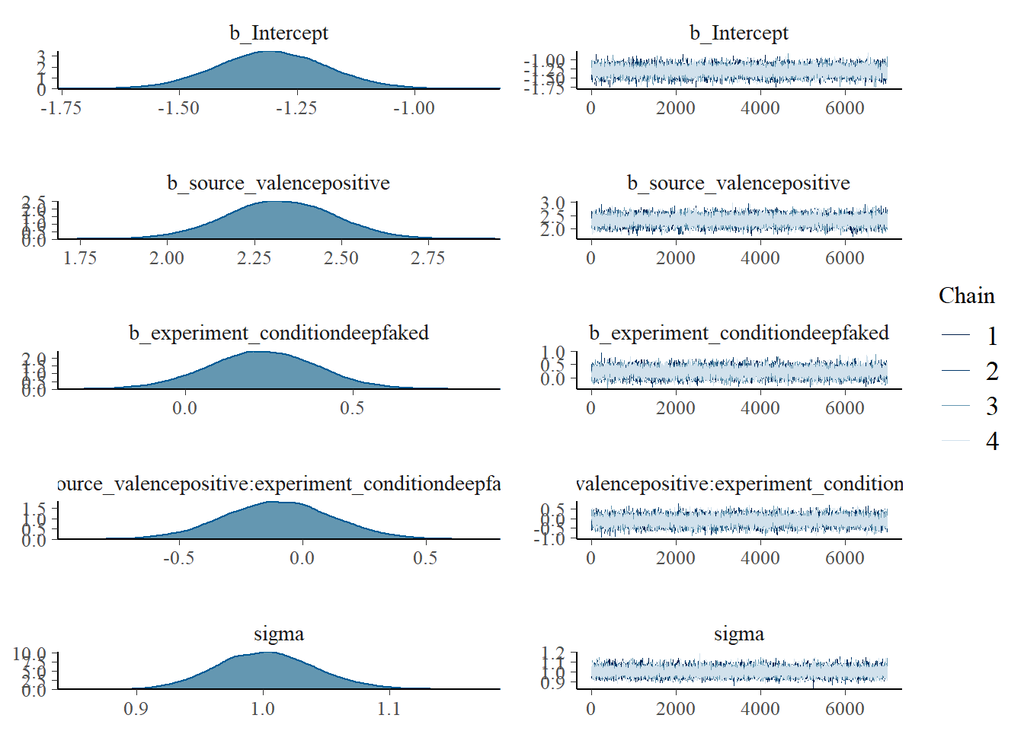

```r
plot(fit_exploratory_selfreport_exp3, ask = FALSE)
```

#### Check informativeness of prior

Using Gelman’s (2019) simple heuristic: For each parameter, compare the posterior sd to the prior sd. If the posterior sd for any parameter is more than 0.1 times the prior sd, then note that the prior was informative.

```r
check_prior(fit_exploratory_selfreport_exp3) %>%
  kable() %>%
  kable_styling(bootstrap_options = c("striped", "hover", "condensed"),
                full_width = FALSE)
```

| Parameter | Prior_Quality |
| --- | --- |
| b_Intercept | uninformative |
| b_source_valencepositive | uninformative |
| b_experiment_conditiondeepfaked | uninformative |
| b_source_valencepositive.experiment_conditiondeepfaked | uninformative |

#### Interpret posteriors

```r
# percent moderation
draws_sr_exp3 <-
  bind_cols(
    select(spread_draws(fit_exploratory_selfreport_exp3, b_source_valencepositive), b_source_valencepositive),
    select(spread_draws(fit_exploratory_selfreport_exp3, b_experiment_conditiondeepfaked), b_experiment_conditiondeepfaked),
    select(spread_draws(fit_exploratory_selfreport_exp3, `b_source_valencepositive:experiment_conditiondeepfaked`), `b_source_valencepositive:experiment_conditiondeepfaked`)
  ) %>%
  rename(main_valence = b_source_valencepositive,
         main_experiment_condition = b_experiment_conditiondeepfaked,
         interaction = `b_source_valencepositive:experiment_conditiondeepfaked`) %>%
  mutate(effect_deepfaked = main_valence + interaction)

# results
estimates_sr_exp3 <-
  map_estimate(draws_sr_exp3) %>%
  full_join(bayestestR::hdi(draws_sr_exp3, ci = .95) %>%
              rename(CI_95_lower = CI_low,
                     CI_95_upper = CI_high) %>%
              as_tibble(),
            by = "Parameter") %>%
  full_join(bayestestR::hdi(draws_sr_exp3, ci = .90) %>%
              as_tibble() %>%
              rename(CI_90_lower = CI_low,
                     CI_90_upper = CI_high),
            by = "Parameter") %>%
  full_join(draws_sr_exp3 %>%
              gather(Parameter, value) %>%
              group_by(Parameter) %>%
              summarize(pd = mean(value > 0)) %>%
              mutate(p = pd_to_p(pd, direction = "one-sided")) %>%
              ungroup() %>%
              select(Parameter, p),
            by = "Parameter") %>%
  select(Parameter, MAP_Estimate, CI_95_lower, CI_95_upper,
         CI_90_lower, CI_90_upper, p)

# results table
estimates_sr_exp3 %>%
  mutate_at(.vars = c("MAP_Estimate", "CI_95_lower", "CI_95_upper", "CI_90_lower", "CI_90_upper"), round, digits = 2) %>%
  kable() %>%
  kable_styling(bootstrap_options = c("striped", "hover", "condensed"),
                full_width = FALSE)
```

| Parameter | MAP_Estimate | CI_95_lower | CI_95_upper | CI_90_lower | CI_90_upper | p |
| --- | --- | --- | --- | --- | --- | --- |
| main_valence | 2.31 | 2.03 | 2.63 | 2.06 | 2.57 | 0.0000000 |
| main_experiment_condition | 0.21 | -0.09 | 0.55 | -0.03 | 0.50 | 0.0795714 |
| interaction | -0.13 | -0.53 | 0.33 | -0.46 | 0.26 | 0.3255357 |
| effect_deepfaked | 2.24 | 1.92 | 2.53 | 1.97 | 2.48 | 0.0000000 |

```r
# hypothesis testing
H1b <- ifelse((estimates_sr_exp3 %>% filter(Parameter == "effect_deepfaked") %>% pull(CI_95_lower)) > 0,
              "Accepted", "Rejected")
```

The content of the Deepfaked videos (i.e., Source Valence) will influence participants’ self-reported evaluations.

- Result: Accepted

### Implicit

#### Fit model

```r
fit_exploratory_implicit_exp3 <-
  data_after_exclusions %>%
  filter(experiment == 3) %>%
  brm(formula = IAT_D2 ~ source_valence * experiment_condition,
      family  = gaussian(),
      data    = .,
      file    = "models/fit_exploratory_implicit_exp3",
      prior   = prior(normal(0, 10)),
      iter    = 10000,
      warmup  = 3000,
      control = list(adapt_delta = 0.99),  # to avoid divergent transitions
      chains  = 4,
      cores   = parallel::detectCores())
```

#### Inspect convergence

```r
summary(fit_exploratory_implicit_exp3)
```

```
##  Family: gaussian
##   Links: mu = identity; sigma = identity
## Formula: IAT_D2 ~ source_valence * experiment_condition
##    Data: . (Number of observations: 337)
## Samples: 4 chains, each with iter = 10000; warmup = 3000; thin = 1;
##          total post-warmup samples = 28000
##
## Population-Level Effects:
##                                                      Estimate Est.Error
## Intercept                                                0.07      0.12
## source_valencepositive                                   1.32      0.15
## experiment_conditiondeepfaked                            0.08      0.16
## source_valencepositive:experiment_conditiondeepfaked    -0.17      0.22
##                                                      l-95% CI u-95% CI Rhat
## Intercept                                               -0.16     0.30 1.00
## source_valencepositive                                   1.02     1.62 1.00
## experiment_conditiondeepfaked                           -0.24     0.39 1.00
## source_valencepositive:experiment_conditiondeepfaked    -0.60     0.26 1.00
##                                                      Bulk_ESS Tail_ESS
## Intercept                                               14099    18231
## source_valencepositive                                  12076    16785
## experiment_conditiondeepfaked                           11913    16404
## source_valencepositive:experiment_conditiondeepfaked    10766    15617
##
## Family Specific Parameters:
##       Estimate Est.Error l-95% CI u-95% CI Rhat Bulk_ESS Tail_ESS
## sigma     1.00      0.04     0.93     1.08 1.00    21022    18026
##
## Samples were drawn using sampling(NUTS). For each parameter, Bulk_ESS
## and Tail_ESS are effective sample size measures, and Rhat is the potential
## scale reduction factor on split chains (at convergence, Rhat = 1).
```

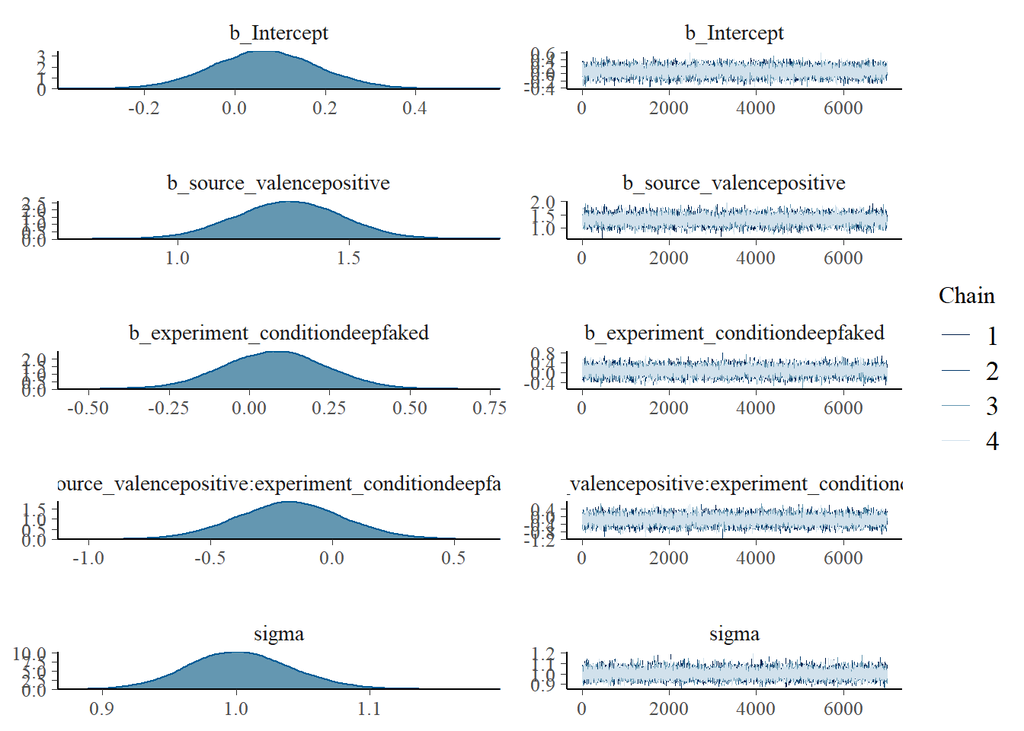

```r
plot(fit_exploratory_implicit_exp3, ask = FALSE)
```

#### Check informativeness of prior

Using Gelman’s (2019) simple heuristic: For each parameter, compare the posterior sd to the prior sd. If the posterior sd for any parameter is more than 0.1 times the prior sd, then note that the prior was informative.

```r
check_prior(fit_exploratory_implicit_exp3) %>%
  kable() %>%
  kable_styling(bootstrap_options = c("striped", "hover", "condensed"),
                full_width = FALSE)
```

| Parameter | Prior_Quality |
| --- | --- |
| b_Intercept | uninformative |
| b_source_valencepositive | uninformative |
| b_experiment_conditiondeepfaked | uninformative |
| b_source_valencepositive.experiment_conditiondeepfaked | uninformative |

#### Interpret posteriors

```r
# percent moderation
draws_imp_exp3 <-
  bind_cols(
    select(spread_draws(fit_exploratory_implicit_exp3, b_source_valencepositive), b_source_valencepositive),
    select(spread_draws(fit_exploratory_implicit_exp3, b_experiment_conditiondeepfaked), b_experiment_conditiondeepfaked),
    select(spread_draws(fit_exploratory_implicit_exp3, `b_source_valencepositive:experiment_conditiondeepfaked`), `b_source_valencepositive:experiment_conditiondeepfaked`)
  ) %>%
  rename(main_valence = b_source_valencepositive,
         main_experiment_condition = b_experiment_conditiondeepfaked,
         interaction = `b_source_valencepositive:experiment_conditiondeepfaked`) %>%
  mutate(effect_deepfaked = main_valence + interaction)

# results table
estimates_imp_exp3 <-
  map_estimate(draws_imp_exp3) %>%
  full_join(bayestestR::hdi(draws_imp_exp3, ci = .95) %>%
              rename(CI_95_lower = CI_low,
                     CI_95_upper = CI_high) %>%
              as_tibble(),
            by = "Parameter") %>%
  full_join(bayestestR::hdi(draws_imp_exp3, ci = .90) %>%
              as_tibble() %>%
              rename(CI_90_lower = CI_low,
                     CI_90_upper = CI_high),
            by = "Parameter") %>%
  full_join(draws_imp_exp3 %>%
              gather(Parameter, value) %>%
              group_by(Parameter) %>%
              summarize(pd = mean(value > 0)) %>%
              mutate(p = pd_to_p(pd, direction = "one-sided")) %>%
              ungroup() %>%
              select(Parameter, p),
            by = "Parameter") %>%
  select(Parameter, MAP_Estimate, CI_95_lower, CI_95_upper,
         CI_90_lower, CI_90_upper, p)

estimates_imp_exp3 %>%
  mutate_at(.vars = c("MAP_Estimate", "CI_95_lower", "CI_95_upper", "CI_90_lower", "CI_90_upper"), round, digits = 2) %>%
  kable() %>%
  kable_styling(bootstrap_options = c("striped", "hover", "condensed"),
                full_width = FALSE)
```

| Parameter | MAP_Estimate | CI_95_lower | CI_95_upper | CI_90_lower | CI_90_upper | p |
| --- | --- | --- | --- | --- | --- | --- |
| main_valence | 1.32 | 1.02 | 1.62 | 1.07 | 1.58 | 0.0000000 |
| main_experiment_condition | 0.08 | -0.24 | 0.39 | -0.17 | 0.35 | 0.3126429 |
| interaction | -0.18 | -0.60 | 0.25 | -0.53 | 0.19 | 0.2117500 |
| effect_deepfaked | 1.16 | 0.85 | 1.45 | 0.89 | 1.40 | 0.0000000 |

```r
# hypothesis testing
H1d <- ifelse((estimates_imp_exp3 %>% filter(Parameter == "effect_deepfaked") %>% pull(CI_95_lower)) > 0,
              "Accepted", "Rejected")
```

The content of the Deepfaked videos (i.e., Source Valence) will influence participants’ IAT D2 scores.

- Result: Accepted

## Evaluative learning effects in deepfaked group from Experiment 4 and 6

### Self-reported evaluations

#### Fit model

```r
fit_exploratory_selfreport_exp46 <-
  data_after_exclusions %>%
  filter(experiment %in% c(4, 6)) %>%
  brm(formula = mean_self_reported_evaluation ~ source_valence * experiment_condition + (1 | experiment),
      family  = gaussian(),
      data    = .,
      file    = "models/fit_exploratory_selfreport_exp46",
      prior   = prior(normal(0, 10)),
      iter    = 10000,
      warmup  = 3000,
      control = list(adapt_delta = 0.99),  # to avoid divergent transitions
      chains  = 4,
      cores   = parallel::detectCores())
```

#### Inspect convergence

```r
summary(fit_exploratory_selfreport_exp46)
```

```
##  Family: gaussian
##   Links: mu = identity; sigma = identity
## Formula: mean_self_reported_evaluation ~ source_valence * experiment_condition + (1 | experiment)
##    Data: . (Number of observations: 527)
## Samples: 4 chains, each with iter = 10000; warmup = 3000; thin = 1;
##          total post-warmup samples = 28000
##
## Group-Level Effects:
## ~experiment (Number of levels: 2)
##               Estimate Est.Error l-95% CI u-95% CI Rhat Bulk_ESS Tail_ESS
## sd(Intercept)     0.99      1.08     0.08     4.03 1.00     5591     8976
##
## Population-Level Effects:
##                                                      Estimate Est.Error
## Intercept                                               -1.48      0.78
## source_valencepositive                                   2.93      0.13
## experiment_conditiondeepfaked                           -0.29      0.13
## source_valencepositive:experiment_conditiondeepfaked     0.28      0.18
##                                                      l-95% CI u-95% CI Rhat
## Intercept                                               -3.25     0.27 1.00
## source_valencepositive                                   2.68     3.18 1.00
## experiment_conditiondeepfaked                           -0.54    -0.04 1.00
## source_valencepositive:experiment_conditiondeepfaked    -0.08     0.64 1.00
##                                                      Bulk_ESS Tail_ESS
## Intercept                                                7166     6195
## source_valencepositive                                  12680    16316
## experiment_conditiondeepfaked                           12586    13514
## source_valencepositive:experiment_conditiondeepfaked    11341    13090
##
## Family Specific Parameters:
##       Estimate Est.Error l-95% CI u-95% CI Rhat Bulk_ESS Tail_ESS
## sigma     1.03      0.03     0.97     1.10 1.00    18666    13087
##
## Samples were drawn using sampling(NUTS). For each parameter, Bulk_ESS
## and Tail_ESS are effective sample size measures, and Rhat is the potential
## scale reduction factor on split chains (at convergence, Rhat = 1).
```

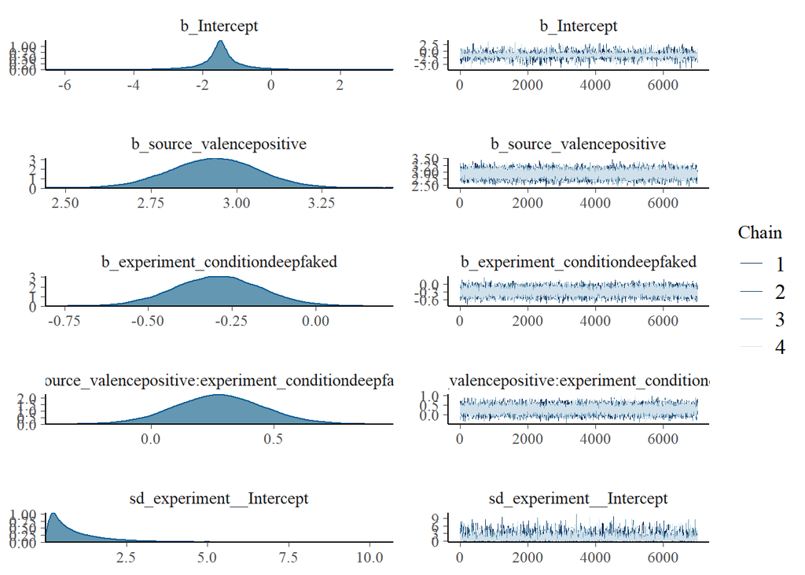

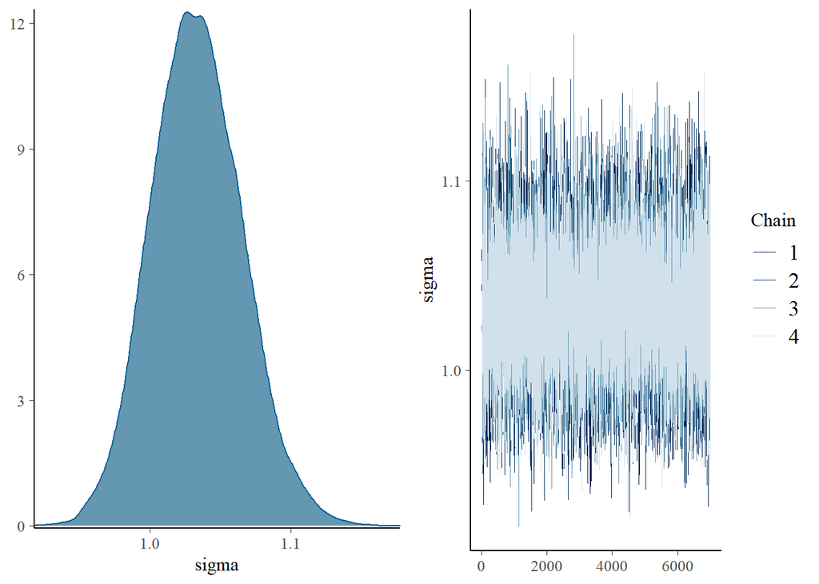

```r
plot(fit_exploratory_selfreport_exp46, ask = FALSE)
```

#### Check informativeness of prior

Using Gelman’s (2019) simple heuristic: For each parameter, compare the posterior sd to the prior sd. If the posterior sd for any parameter is more than 0.1 times the prior sd, then note that the prior was informative.

```r
check_prior(fit_exploratory_selfreport_exp46) %>%
  kable() %>%
  kable_styling(bootstrap_options = c("striped", "hover", "condensed"),
                full_width = FALSE)
```

| Parameter | Prior_Quality |
| --- | --- |
| b_Intercept | uninformative |
| b_source_valencepositive | uninformative |
| b_experiment_conditiondeepfaked | uninformative |
| b_source_valencepositive.experiment_conditiondeepfaked | uninformative |

#### Interpret posteriors

```r
# percent moderation
draws_sr_exp46 <-
  bind_cols(
    select(spread_draws(fit_exploratory_selfreport_exp46, b_source_valencepositive), b_source_valencepositive),
    select(spread_draws(fit_exploratory_selfreport_exp46, b_experiment_conditiondeepfaked), b_experiment_conditiondeepfaked),
    select(spread_draws(fit_exploratory_selfreport_exp46, `b_source_valencepositive:experiment_conditiondeepfaked`), `b_source_valencepositive:experiment_conditiondeepfaked`)
  ) %>%
  rename(main_valence = b_source_valencepositive,
         main_experiment_condition = b_experiment_conditiondeepfaked,
         interaction = `b_source_valencepositive:experiment_conditiondeepfaked`) %>%
  mutate(effect_deepfaked = main_valence + interaction)

# results
estimates_sr_exp46 <-
  map_estimate(draws_sr_exp46) %>%
  full_join(bayestestR::hdi(draws_sr_exp46, ci = .95) %>%
              rename(CI_95_lower = CI_low,
                     CI_95_upper = CI_high) %>%
              as_tibble(),
            by = "Parameter") %>%
  full_join(bayestestR::hdi(draws_sr_exp46, ci = .90) %>%
              as_tibble() %>%
              rename(CI_90_lower = CI_low,
                     CI_90_upper = CI_high),
            by = "Parameter") %>%
  full_join(draws_sr_exp46 %>%
              gather(Parameter, value) %>%
              group_by(Parameter) %>%
              summarize(pd = mean(value > 0)) %>%
              mutate(p = pd_to_p(pd, direction = "one-sided")) %>%
              ungroup() %>%
              select(Parameter, p),
            by = "Parameter") %>%
  select(Parameter, MAP_Estimate, CI_95_lower, CI_95_upper,
         CI_90_lower, CI_90_upper, p)

# results table
estimates_sr_exp46 %>%
  mutate_at(.vars = c("MAP_Estimate", "CI_95_lower", "CI_95_upper", "CI_90_lower", "CI_90_upper"), round, digits = 2) %>%
  kable() %>%
  kable_styling(bootstrap_options = c("striped", "hover", "condensed"),
                full_width = FALSE)
```

| Parameter | MAP_Estimate | CI_95_lower | CI_95_upper | CI_90_lower | CI_90_upper | p |
| --- | --- | --- | --- | --- | --- | --- |
| main_valence | 2.93 | 2.68 | 3.18 | 2.72 | 3.14 | 0.0000000 |
| main_experiment_condition | -0.30 | -0.55 | -0.05 | -0.50 | -0.08 | 0.0122500 |
| interaction | 0.27 | -0.09 | 0.63 | -0.02 | 0.58 | 0.0613929 |
| effect_deepfaked | 3.21 | 2.97 | 3.47 | 3.01 | 3.42 | 0.0000000 |

```r
# hypothesis testing
H1b <- ifelse((estimates_sr_exp46 %>% filter(Parameter == "effect_deepfaked") %>% pull(CI_95_lower)) > 0,
              "Accepted", "Rejected")
```

The content of the Deepfaked videos (i.e., Source Valence) will influence participants’ self-reported evaluations.

- Result: Accepted

### Implicit

#### Fit model

```r
fit_exploratory_implicit_exp46 <-
  data_after_exclusions %>%
  filter(experiment %in% c(4, 6)) %>%
  brm(formula = IAT_D2 ~ source_valence * experiment_condition + (1 | experiment),
      family  = gaussian(),
      data    = .,
      file    = "models/fit_exploratory_implicit_exp46",
      prior   = prior(normal(0, 10)),
      iter    = 10000,
      warmup  = 3000,
      control = list(adapt_delta = 0.99),  # to avoid divergent transitions
      chains  = 4,
      cores   = parallel::detectCores())
```

#### Inspect convergence

```r
summary(fit_exploratory_implicit_exp46)
```

```
##  Family: gaussian
##   Links: mu = identity; sigma = identity
## Formula: IAT_D2 ~ source_valence * experiment_condition + (1 | experiment)
##    Data: . (Number of observations: 527)
## Samples: 4 chains, each with iter = 10000; warmup = 3000; thin = 1;
##          total post-warmup samples = 28000
##
## Group-Level Effects:
## ~experiment (Number of levels: 2)
##               Estimate Est.Error l-95% CI u-95% CI Rhat Bulk_ESS Tail_ESS
## sd(Intercept)     0.98      1.07     0.10     3.95 1.00     6667    11523
##
## Population-Level Effects:
##                                                      Estimate Est.Error
## Intercept                                               -0.04      0.77
## source_valencepositive                                   1.22      0.12
## experiment_conditiondeepfaked                            0.13      0.12
## source_valencepositive:experiment_conditiondeepfaked     0.19      0.17
##                                                      l-95% CI u-95% CI Rhat
## Intercept                                               -1.72     1.64 1.00
## source_valencepositive                                   0.97     1.46 1.00
## experiment_conditiondeepfaked                           -0.11     0.38 1.00
## source_valencepositive:experiment_conditiondeepfaked    -0.14     0.53 1.00
##                                                      Bulk_ESS Tail_ESS
## Intercept                                                8627     9587
## source_valencepositive                                  13386    17131
## experiment_conditiondeepfaked                           12468    16604
## source_valencepositive:experiment_conditiondeepfaked    11744    15712
##
## Family Specific Parameters:
##       Estimate Est.Error l-95% CI u-95% CI Rhat Bulk_ESS Tail_ESS
## sigma     1.00      0.03     0.94     1.07 1.00    17736    16143
##
## Samples were drawn using sampling(NUTS). For each parameter, Bulk_ESS
## and Tail_ESS are effective sample size measures, and Rhat is the potential
## scale reduction factor on split chains (at convergence, Rhat = 1).
```

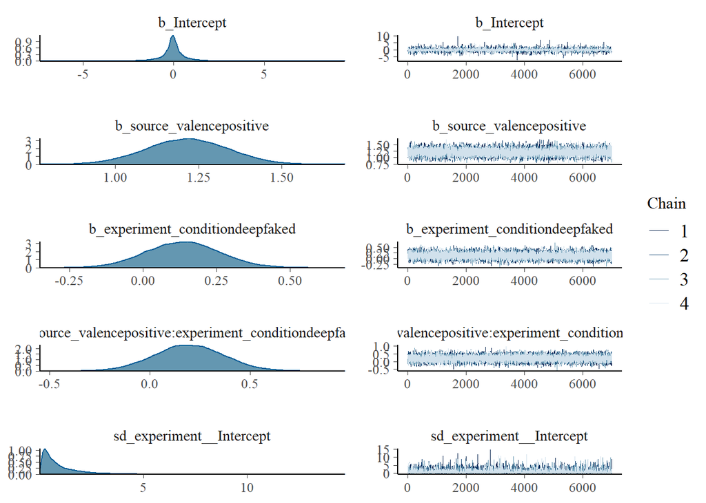

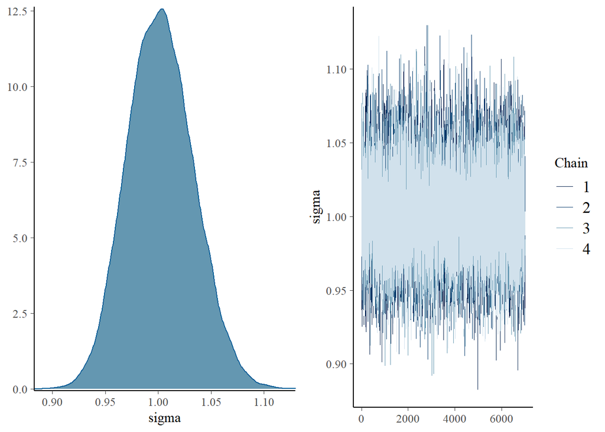

```r
plot(fit_exploratory_implicit_exp46, ask = FALSE)
```

#### Check informativeness of prior

Using Gelman’s (2019) simple heuristic: For each parameter, compare the posterior sd to the prior sd. If the posterior sd for any parameter is more than 0.1 times the prior sd, then note that the prior was informative.

```r
check_prior(fit_exploratory_implicit_exp46) %>%
  kable() %>%
  kable_styling(bootstrap_options = c("striped", "hover", "condensed"),
                full_width = FALSE)
```

| Parameter | Prior_Quality |
| --- | --- |
| b_Intercept | uninformative |
| b_source_valencepositive | uninformative |
| b_experiment_conditiondeepfaked | uninformative |
| b_source_valencepositive.experiment_conditiondeepfaked | uninformative |

#### Interpret posteriors

```r
# percent moderation
draws_imp_exp46 <-
  bind_cols(
    select(spread_draws(fit_exploratory_implicit_exp46, b_source_valencepositive), b_source_valencepositive),
    select(spread_draws(fit_exploratory_implicit_exp46, b_experiment_conditiondeepfaked), b_experiment_conditiondeepfaked),
    select(spread_draws(fit_exploratory_implicit_exp46, `b_source_valencepositive:experiment_conditiondeepfaked`), `b_source_valencepositive:experiment_conditiondeepfaked`)
  ) %>%
  rename(main_valence = b_source_valencepositive,
         main_experiment_condition = b_experiment_conditiondeepfaked,
         interaction = `b_source_valencepositive:experiment_conditiondeepfaked`) %>%
  mutate(effect_deepfaked = main_valence + interaction)

# results table
estimates_imp_exp46 <-
  map_estimate(draws_imp_exp46) %>%
  full_join(bayestestR::hdi(draws_imp_exp46, ci = .95) %>%
              rename(CI_95_lower = CI_low,
                     CI_95_upper = CI_high) %>%
              as_tibble(),
            by = "Parameter") %>%
  full_join(bayestestR::hdi(draws_imp_exp46, ci = .90) %>%
              as_tibble() %>%
              rename(CI_90_lower = CI_low,
                     CI_90_upper = CI_high),
            by = "Parameter") %>%
  full_join(draws_imp_exp46 %>%
              gather(Parameter, value) %>%
              group_by(Parameter) %>%
              summarize(pd = mean(value > 0)) %>%
              mutate(p = pd_to_p(pd, direction = "one-sided")) %>%
              ungroup() %>%
              select(Parameter, p),
            by = "Parameter") %>%
  select(Parameter, MAP_Estimate, CI_95_lower, CI_95_upper,
         CI_90_lower, CI_90_upper, p)

estimates_imp_exp46 %>%
  mutate_at(.vars = c("MAP_Estimate", "CI_95_lower", "CI_95_upper", "CI_90_lower", "CI_90_upper"), round, digits = 2) %>%
  kable() %>%
  kable_styling(bootstrap_options = c("striped", "hover", "condensed"),
                full_width = FALSE)
```

| Parameter | MAP_Estimate | CI_95_lower | CI_95_upper | CI_90_lower | CI_90_upper | p |
| --- | --- | --- | --- | --- | --- | --- |
| main_valence | 1.22 | 0.98 | 1.46 | 1.01 | 1.42 | 0.0000000 |
| main_experiment_condition | 0.15 | -0.11 | 0.37 | -0.07 | 0.34 | 0.1397143 |
| interaction | 0.18 | -0.15 | 0.52 | -0.09 | 0.48 | 0.1285357 |
| effect_deepfaked | 1.41 | 1.17 | 1.65 | 1.21 | 1.61 | 0.0000000 |

```r
# hypothesis testing
H1d <- ifelse((estimates_imp_exp46 %>% filter(Parameter == "effect_deepfaked") %>% pull(CI_95_lower)) > 0,
              "Accepted", "Rejected")
```

The content of the Deepfaked videos (i.e., Source Valence) will influence participants’ IAT D2 scores.

- Result: Accepted

### Behavioural intentions

#### Fit model

```r
fit_exploratory_intentions_exp46 <-
  data_after_exclusions %>%
  filter(experiment %in% c(4, 6)) %>%
  brm(formula = mean_intentions ~ source_valence * experiment_condition, # no random effect for experiment as only exp 6 assessed intentions
      family  = gaussian(),
      data    = .,
      file    = "models/fit_exploratory_intentions_exp46",
      prior   = prior(normal(0, 10)),
      iter    = 10000,
      warmup  = 3000,
      control = list(adapt_delta = 0.99),  # to avoid divergent transitions
      chains  = 4,
      cores   = parallel::detectCores())
```

#### Inspect convergence

```r
summary(fit_exploratory_intentions_exp46)
```

```
##  Family: gaussian
##   Links: mu = identity; sigma = identity
## Formula: mean_intentions ~ source_valence * experiment_condition
##    Data: . (Number of observations: 204)
## Samples: 4 chains, each with iter = 10000; warmup = 3000; thin = 1;
##          total post-warmup samples = 28000
##
## Population-Level Effects:
##                                                      Estimate Est.Error
## Intercept                                               -1.63      0.14
## source_valencepositive                                   1.12      0.20
## experiment_conditiondeepfaked                           -1.70      0.21
## source_valencepositive:experiment_conditiondeepfaked     1.95      0.28
##                                                      l-95% CI u-95% CI Rhat
## Intercept                                               -1.92    -1.35 1.00
## source_valencepositive                                   0.72     1.52 1.00
## experiment_conditiondeepfaked                           -2.11    -1.29 1.00
## source_valencepositive:experiment_conditiondeepfaked     1.39     2.51 1.00
##                                                      Bulk_ESS Tail_ESS
## Intercept                                               14514    17958
## source_valencepositive                                  12689    15830
## experiment_conditiondeepfaked                           12871    16431
## source_valencepositive:experiment_conditiondeepfaked    11165    14802
##
## Family Specific Parameters:
##       Estimate Est.Error l-95% CI u-95% CI Rhat Bulk_ESS Tail_ESS
## sigma     1.01      0.05     0.91     1.11 1.00    19078    17592
##
## Samples were drawn using sampling(NUTS). For each parameter, Bulk_ESS
## and Tail_ESS are effective sample size measures, and Rhat is the potential
## scale reduction factor on split chains (at convergence, Rhat = 1).
```

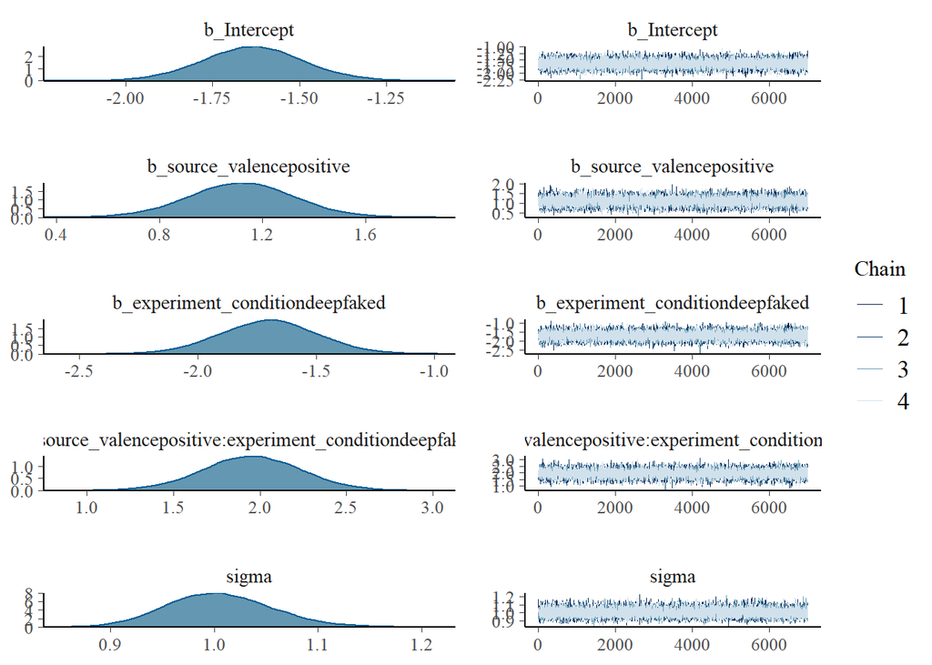

```r
plot(fit_exploratory_intentions_exp46, ask = FALSE)
```

#### Check informativeness of prior

Using Gelman’s (2019) simple heuristic: For each parameter, compare the posterior sd to the prior sd. If the posterior sd for any parameter is more than 0.1 times the prior sd, then note that the prior was informative.

```r
check_prior(fit_exploratory_intentions_exp46) %>%
  kable() %>%
  kable_styling(bootstrap_options = c("striped", "hover", "condensed"),
                full_width = FALSE)
```

| Parameter | Prior_Quality |
| --- | --- |
| b_Intercept | uninformative |
| b_source_valencepositive | uninformative |
| b_experiment_conditiondeepfaked | uninformative |
| b_source_valencepositive.experiment_conditiondeepfaked | uninformative |

#### Interpret posteriors

```r
# percent moderation
draws_intentions_intentions_exp46 <-
  bind_cols(
    select(spread_draws(fit_exploratory_intentions_exp46, b_source_valencepositive), b_source_valencepositive),
    select(spread_draws(fit_exploratory_intentions_exp46, b_experiment_conditiondeepfaked), b_experiment_conditiondeepfaked),
    select(spread_draws(fit_exploratory_intentions_exp46, `b_source_valencepositive:experiment_conditiondeepfaked`), `b_source_valencepositive:experiment_conditiondeepfaked`)
  ) %>%
  rename(main_valence = b_source_valencepositive,
         main_experiment_condition = b_experiment_conditiondeepfaked,
         interaction = `b_source_valencepositive:experiment_conditiondeepfaked`) %>%
  mutate(effect_deepfaked = main_valence + interaction)

# results table
estimates_intentions_intentions_exp46 <-
  map_estimate(draws_intentions_intentions_exp46) %>%
  full_join(bayestestR::hdi(draws_intentions_intentions_exp46, ci = .95) %>%
              rename(CI_95_lower = CI_low,
                     CI_95_upper = CI_high) %>%
              as_tibble(),
            by = "Parameter") %>%
  full_join(bayestestR::hdi(draws_intentions_intentions_exp46, ci = .90) %>%
              as_tibble() %>%
              rename(CI_90_lower = CI_low,
                     CI_90_upper = CI_high),
            by = "Parameter") %>%
  full_join(draws_intentions_intentions_exp46 %>%
              gather(Parameter, value) %>%
              group_by(Parameter) %>%
              summarize(pd = mean(value > 0)) %>%
              mutate(p = pd_to_p(pd, direction = "one-sided")) %>%
              ungroup() %>%
              select(Parameter, p),
            by = "Parameter") %>%
  select(Parameter, MAP_Estimate, CI_95_lower, CI_95_upper,
         CI_90_lower, CI_90_upper, p)

estimates_intentions_intentions_exp46 %>%
  mutate_at(.vars = c("MAP_Estimate", "CI_95_lower", "CI_95_upper", "CI_90_lower", "CI_90_upper"), round, digits = 2) %>%
  kable() %>%
  kable_styling(bootstrap_options = c("striped", "hover", "condensed"),
                full_width = FALSE)
```

| Parameter | MAP_Estimate | CI_95_lower | CI_95_upper | CI_90_lower | CI_90_upper | p |
| --- | --- | --- | --- | --- | --- | --- |
| main_valence | 1.12 | 0.72 | 1.52 | 0.77 | 1.44 | 0 |
| main_experiment_condition | -1.69 | -2.09 | -1.28 | -2.04 | -1.36 | 0 |
| interaction | 1.97 | 1.40 | 2.51 | 1.49 | 2.43 | 0 |
| effect_deepfaked | 3.06 | 2.68 | 3.46 | 2.75 | 3.40 | 0 |

```r
# hypothesis testing
H1f <- ifelse((estimates_intentions_intentions_exp46 %>% filter(Parameter == "effect_deepfaked") %>% pull(CI_95_lower)) > 0,
              "Accepted", "Rejected")
```

The content of the Deepfaked videos (i.e., Source Valence) will influence participants’ behavioral intention responses.

- Result: Accepted